# Exploring potential explanations for eligibility drift

Author

Xing Song

## Clinic BP vs. Home BP at Baseline

Run-in period is defined as the time gap between eligibility clinic visit and baseline visit.

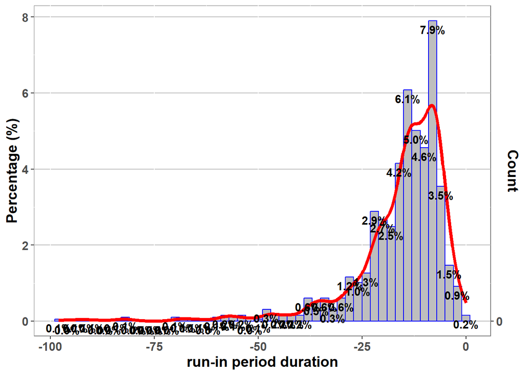

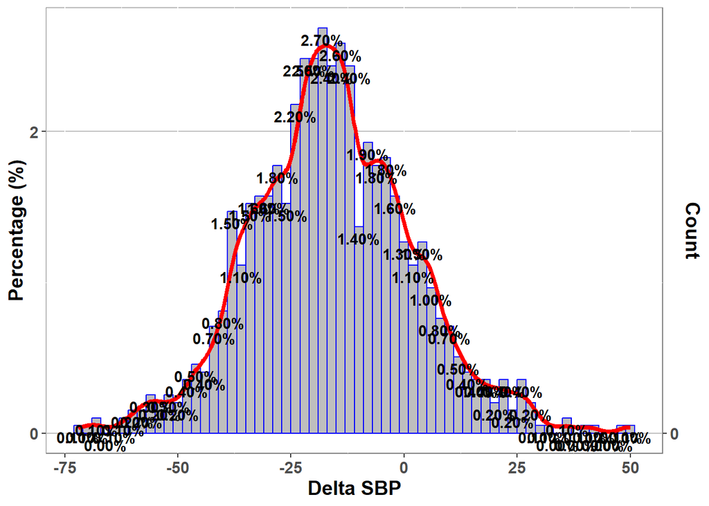

## Investigation: How much of the eligibility drift can be explained by anti-hypertensive medication use during the run-in period?

We set out to investigate what could be some legitimate reasons occured during the run-in period (i.e., the time period between eligibility and recruitment/randomization) to explain this eligibility drift. For this investigation, we also collected all prescription data from CDM PRESCRIBING table provided by KUMC team and identified the following anti-HTN medications (using VA classifications) as well as their timings (start before eligibility visit or during the run-in period):

- CV100: beta blockers/related
- CV150: alpha blockers/related
- CV200: calcium channel blockers
- CV400: anti-hypertensive combinations
- CV490: antihypertensive, others
- CV701: thiazides/related diuretics
- CV702: loop diuretics
- CV703: carbonic anhydrase inhibitor diuretics
- CV704: potassium sparing/combinations diretics
- CV709: diuretics, other
- CV800: ACE inhibitors
- CV805: angiotensin II inhibitor
- CV806: direct renin inhibitor

### Analysis I: Using systematic explanatory feature screening to investigate what are the explanatory factors for significant BP drop

```
                     Stratified by antihtn_delta_med
                      UNEXPLD     RUNIN_MT    RUNIN_RXUP p      test
  n                   395         531         74
  DELTA_SBP_GROUP (%)                                     0.148
     deltasbp1        164 (41.5)  195 (36.7)  36 (48.6)
     deltasbp2         96 (24.3)  121 (22.8)  14 (18.9)
     deltasbp3        135 (34.2)  215 (40.5)  24 (32.4)
```

```
                       Stratified by DELTA_SBP_GROUP
                        deltasbp1   deltasbp2   deltasbp3   p      test
  n                     395         231         374
  antihtn_delta_med (%)                                      0.148
     UNEXPLD            164 (41.5)   96 (41.6)  135 (36.1)
     RUNIN_MT           195 (49.4)  121 (52.4)  215 (57.5)
     RUNIN_RXUP          36 ( 9.1)   14 ( 6.1)   24 ( 6.4)
```

```
                        Stratified by antihtn_delta_med
                         UNEXPLD     RUNIN_MT    RUNIN_RXUP p      test
  n                      395         531         74
  DELTA_SBP_BY10_GRP (%)                                     0.245
     -4                   32 ( 8.1)   29 ( 5.5)   8 (10.8)
     -3                   58 (14.7)   58 (10.9)  14 (18.9)
     -2                   79 (20.0)  101 (19.0)  12 (16.2)
     -1                   97 (24.6)  138 (26.0)  16 (21.6)
     0                   104 (26.3)  161 (30.3)  20 (27.0)
     1                    25 ( 6.3)   44 ( 8.3)   4 ( 5.4)
```

```
                       Stratified by DELTA_SBP_BY10_GRP
                        -4         -3          -2          -1
  n                     69         130         192         251
  antihtn_delta_med (%)
     UNEXPLD            32 (46.4)   58 (44.6)   79 (41.1)   97 (38.6)
     RUNIN_MT           29 (42.0)   58 (44.6)  101 (52.6)  138 (55.0)
     RUNIN_RXUP          8 (11.6)   14 (10.8)   12 ( 6.2)   16 ( 6.4)
                       Stratified by DELTA_SBP_BY10_GRP
                        0           1          p      test
  n                     285         73
  antihtn_delta_med (%)                         0.245
     UNEXPLD            104 (36.5)  25 (34.2)
     RUNIN_MT           161 (56.5)  44 (60.3)
     RUNIN_RXUP          20 ( 7.0)   4 ( 5.5)
```

```
                          Stratified by antihtn_delta_med
                           UNEXPLD     RUNIN_MT    RUNIN_RXUP p      test
  n                        395         531         74
  delta_sbp_over10 = 1 (%) 291 (73.7)  370 (69.7)  54 (73.0)   0.395
```

```
                       Stratified by delta_sbp_over10
                        0           1           p      test
  n                     285         715
  antihtn_delta_med (%)                          0.395
     UNEXPLD            104 (36.5)  291 (40.7)
     RUNIN_MT           161 (56.5)  370 (51.7)
     RUNIN_RXUP          20 ( 7.0)   54 ( 7.6)
```

```
                           Stratified by antihtn_delta_med
                            UNEXPLD     RUNIN_MT    RUNIN_RXUP p      test
  n                         395         531         74
  delta_sbp_over10_sign (%)                                     0.367
     -1                     266 (67.3)  326 (61.4)  50 (67.6)
     +1                      25 ( 6.3)   44 ( 8.3)   4 ( 5.4)
     0                      104 (26.3)  161 (30.3)  20 (27.0)
```

```
                       Stratified by delta_sbp_over10by10
                        1           2           3           p      test
  n                     285         292         423
  antihtn_delta_med (%)                                      0.061
     UNEXPLD            104 (36.5)  107 (36.6)  184 (43.5)
     RUNIN_MT           161 (56.5)  168 (57.5)  202 (47.8)
     RUNIN_RXUP          20 ( 7.0)   17 ( 5.8)   37 ( 8.7)
```

```
                          Stratified by antihtn_delta_med
                           UNEXPLD     RUNIN_MT    RUNIN_RXUP p      test
  n                        395         531         74
  delta_sbp_over10by10 (%)                                     0.061
     1                     104 (26.3)  161 (30.3)  20 (27.0)
     2                     107 (27.1)  168 (31.6)  17 (23.0)
     3                     184 (46.6)  202 (38.0)  37 (50.0)
```

#### Univariate filtering

```
test variable: SITE
```

```
test variable: ELIG_SBP
```

```
test variable: BASE_SBP
```

```
test variable: DELTA_DAYS
```

```
test variable: ESBP_GROUP
```

```
test variable: ELIG_SINCE_INDEX
```

```
test variable: SEX_STR
```

```
test variable: RACE_STR
```

```
test variable: ETHN_STR
```

```
test variable: URM_IND
```

```
test variable: AGE
```

```
test variable: ACS_TOT_POP_WT
```

```
test variable: ACS_TOT_POP_US_ABOVE1
```

```
test variable: ACS_TOT_POP_ABOVE5
```

```
test variable: ACS_TOT_POP_ABOVE15
```

```
test variable: ACS_TOT_POP_ABOVE16
```

```
test variable: ACS_TOT_POP_16_19
```

```
test variable: ACS_TOT_POP_ABOVE25
```

```
test variable: ACS_TOT_CIVIL_POP_ABOVE18
```

```
test variable: ACS_TOT_CIVIL_VET_POP_ABOVE25
```

```
test variable: ACS_TOT_OWN_CHILD_BELOW17
```

```
test variable: ACS_TOT_CIVILIAN_LABOR
```

```
test variable: ACS_TOT_CIVIL_EMPLOY_POP
```

```
test variable: ACS_TOT_WORKER_HH
```

```
test variable: ACS_TOT_WORKER_NWFH
```

```
test variable: ACS_TOT_CIVIL_NONINST_POP_POV
```

```
test variable: ACS_TOT_CIVIL_POP_POV
```

```
test variable: ACS_TOT_POP_POV
```

```
test variable: ACS_TOT_GRANDCHILDREN_GP
```

```
test variable: ACS_TOT_HU
```

```
test variable: ACS_TOT_HH
```

```
test variable: ACS_AVG_HH_SIZE
```

```
test variable: ACS_TOT_CIVIL_NONINST_POP
```

```
test variable: ACS_TOT_CIVIL_VET_POP
```

```
test variable: ACS_PCT_CHILD_DISAB
```

```
test variable: ACS_PCT_DISABLE
```

```
test variable: ACS_PCT_NONVET_DISABLE_18_64
```

```
test variable: ACS_PCT_VET_DISABLE_18_64
```

```
test variable: ACS_PCT_FEMALE
```

```
test variable: ACS_PCT_MALE
```

```
test variable: ACS_PCT_CTZ_ABOVE18
```

```
test variable: ACS_PCT_CTZ_NATURALIZED
```

```
test variable: ACS_PCT_CTZ_NONUS_BORN
```

```
test variable: ACS_PCT_CTZ_US_BORN
```

```
test variable: ACS_PCT_FOREIGN_BORN
```

```
test variable: ACS_PCT_NON_CITIZEN
```

```
test variable: ACS_PCT_NONCTN_1990
```

```
test variable: ACS_PCT_NONCTN_1999
```

```
test variable: ACS_PCT_NONCTN_2000
```

```
test variable: ACS_PCT_NONCTN_2010
```

```
test variable: ACS_PCT_API_LANG
```

```
test variable: ACS_PCT_ENGL_NOT_ALL
```

```
test variable: ACS_PCT_ENGL_NOT_WELL
```

```
test variable: ACS_PCT_ENGL_VERY_WELL
```

```
test variable: ACS_PCT_ENGL_WELL
```

```
test variable: ACS_PCT_ENGLISH
```

```
test variable: ACS_PCT_HH_LIMIT_ENGLISH
```

```
test variable: ACS_PCT_OTH_EURP
```

```
test variable: ACS_PCT_OTH_LANG
```

```
test variable: ACS_PCT_SPANISH
```

```
test variable: ACS_PCT_GULFWAR_1990_2001
```

```
test variable: ACS_PCT_GULFWAR_2001
```

```
test variable: ACS_PCT_GULFWAR_VIETNAM
```

```
test variable: ACS_PCT_VET
```

```
test variable: ACS_PCT_VIETNAM
```

```
test variable: ACS_MEDIAN_AGE
```

```
test variable: ACS_MEDIAN_AGE_FEMALE
```

```
test variable: ACS_MEDIAN_AGE_MALE
```

```
test variable: ACS_PCT_AGE_0_4
```

```
test variable: ACS_PCT_AGE_5_9
```

```
test variable: ACS_PCT_AGE_10_14
```

```
test variable: ACS_PCT_AGE_15_17
```

```
test variable: ACS_PCT_AGE_0_17
```

```
test variable: ACS_PCT_AGE_18_29
```

```
test variable: ACS_PCT_AGE_18_44
```

```
test variable: ACS_PCT_AGE_30_44
```

```
test variable: ACS_PCT_AGE_45_64
```

```
test variable: ACS_PCT_AGE_50_64
```

```
test variable: ACS_PCT_AGE_ABOVE65
```

```
test variable: ACS_PCT_AGE_ABOVE80
```

```
test variable: ACS_PCT_AIAN
```

```
test variable: ACS_PCT_AIAN_FEMALE
```

```
test variable: ACS_PCT_AIAN_MALE
```

```
test variable: ACS_PCT_AIAN_NONHISP
```

```
test variable: ACS_PCT_ASIAN
```

```
test variable: ACS_PCT_ASIAN_FEMALE
```

```
test variable: ACS_PCT_ASIAN_MALE
```

```
test variable: ACS_PCT_ASIAN_NONHISP
```

```
test variable: ACS_PCT_BLACK
```

```
test variable: ACS_PCT_BLACK_FEMALE
```

```
test variable: ACS_PCT_BLACK_MALE
```

```
test variable: ACS_PCT_BLACK_NONHISP
```

```
test variable: ACS_PCT_HISP_FEMALE
```

```
test variable: ACS_PCT_HISP_MALE
```

```
test variable: ACS_PCT_HISPANIC
```

```
test variable: ACS_PCT_MULT_RACE
```

```
test variable: ACS_PCT_MULT_RACE_FEMALE
```

```
test variable: ACS_PCT_MULT_RACE_MALE
```

```
test variable: ACS_PCT_MULT_RACE_NONHISP
```

```
test variable: ACS_PCT_NHPI
```

```
test variable: ACS_PCT_NHPI_FEMALE
```

```
test variable: ACS_PCT_NHPI_MALE
```

```
test variable: ACS_PCT_NHPI_NONHISP
```

```
test variable: ACS_PCT_OTHER_FEMALE
```

```
test variable: ACS_PCT_OTHER_MALE
```

```
test variable: ACS_PCT_OTHER_NONHISP
```

```
test variable: ACS_PCT_OTHER_RACE
```

```
test variable: ACS_PCT_WHITE
```

```
test variable: ACS_PCT_WHITE_FEMALE
```

```
test variable: ACS_PCT_WHITE_MALE
```

```
test variable: ACS_PCT_WHITE_NONHISP
```

```
test variable: ACS_PCT_HOUSEHOLDER_WHITE
```

```
test variable: ACS_PCT_HOUSEHOLDER_BLACK
```

```
test variable: ACS_PCT_HOUSEHOLDER_AIAN
```

```
test variable: ACS_PCT_HOUSEHOLDER_ASIAN
```

```
test variable: ACS_PCT_HOUSEHOLDER_NHPI
```

```
test variable: ACS_PCT_HOUSEHOLDER_OTHER
```

```
test variable: ACS_PCT_HOUSEHOLDER_MULT
```

```
test variable: ACS_PCT_AIAN_COMB
```

```
test variable: ACS_PCT_ASIAN_COMB
```

```
test variable: ACS_PCT_BLACK_COMB
```

```
test variable: ACS_PCT_NHPI_COMB
```

```
test variable: ACS_PCT_WHITE_COMB
```

```
test variable: ACS_PCT_HH_NO_COMP_DEV
```

```
test variable: ACS_PCT_HH_SMARTPHONE
```

```
test variable: ACS_PCT_HH_SMARTPHONE_ONLY
```

```
test variable: ACS_PCT_HH_TABLET
```

```
test variable: ACS_PCT_HH_TABLET_ONLY
```

```
test variable: ACS_PCT_HH_PC
```

```
test variable: ACS_PCT_HH_PC_ONLY
```

```
test variable: ACS_PCT_HH_OTHER_COMP
```

```
test variable: ACS_PCT_HH_OTHER_COMP_ONLY
```

```
test variable: ACS_PCT_HH_INTERNET
```

```
test variable: ACS_PCT_HH_INTERNET_NO_SUBS
```

```
test variable: ACS_PCT_HH_BROADBAND
```

```
test variable: ACS_PCT_HH_BROADBAND_ONLY
```

```
test variable: ACS_PCT_HH_BROADBAND_ANY
```

```
test variable: ACS_PCT_HH_CELLULAR
```

```
test variable: ACS_PCT_HH_CELLULAR_ONLY
```

```
test variable: ACS_PCT_HH_NO_INTERNET
```

```
test variable: ACS_PCT_HH_SAT_INTERNET
```

```
test variable: ACS_PCT_HH_DIAL_INTERNET_ONLY
```

```
test variable: ACS_PCT_CHILD_1FAM
```

```
test variable: ACS_PCT_CHILDREN_GRANDPARENT
```

```
test variable: ACS_PCT_GRANDP_RESPS_NO_P
```

```
test variable: ACS_PCT_GRANDP_RESPS_P
```

```
test variable: ACS_PCT_GRANDP_NO_RESPS
```

```
test variable: ACS_PCT_HH_KID_1PRNT
```

```
test variable: ACS_PCT_DIVORCED_F
```

```
test variable: ACS_PCT_DIVORCED_M
```

```
test variable: ACS_PCT_MARRIED_SP_AB_F
```

```
test variable: ACS_PCT_MARRIED_SP_AB_M
```

```
test variable: ACS_PCT_MARRIED_SP_PR_F
```

```
test variable: ACS_PCT_MARRIED_SP_PR_M
```

```
test variable: ACS_PCT_NVR_MARRIED_F
```

```
test variable: ACS_PCT_NVR_MARRIED_M
```

```
test variable: ACS_PCT_WIDOWED_F
```

```
test variable: ACS_PCT_WIDOWED_M
```

```
test variable: ACS_PCT_POP_SAME_SEX_UNMRD_P
```

```
test variable: ACS_PCT_POP_SAME_SEX_SPOUSE
```

```
test variable: ACS_PCT_ADMIN
```

```
test variable: ACS_PCT_ARMED_FORCES
```

```
test variable: ACS_PCT_ART
```

```
test variable: ACS_PCT_CONSTRUCT
```

```
test variable: ACS_PCT_EDUC
```

```
test variable: ACS_PCT_EMPLOYED
```

```
test variable: ACS_PCT_FINANCE
```

```
test variable: ACS_PCT_GOVT
```

```
test variable: ACS_PCT_INFORM
```

```
test variable: ACS_PCT_MANUFACT
```

```
test variable: ACS_PCT_NATURE
```

```
test variable: ACS_PCT_NOT_LABOR
```

```
test variable: ACS_PCT_OTHER
```

```
test variable: ACS_PCT_PROFESS
```

```
test variable: ACS_PCT_PVT_NONPROFIT
```

```
test variable: ACS_PCT_PVT_PROFIT
```

```
test variable: ACS_PCT_RETAIL
```

```
test variable: ACS_PCT_TRANSPORT
```

```
test variable: ACS_PCT_UNEMPLOY
```

```
test variable: ACS_PCT_VET_LABOR_FORCE_18_64
```

```
test variable: ACS_PCT_VET_UNEMPL_18_64
```

```
test variable: ACS_PCT_WHOLESALE
```

```
test variable: ACS_PCT_WORK_RES_F
```

```
test variable: ACS_PCT_WORK_RES_M
```

```
test variable: ACS_GINI_INDEX
```

```
test variable: ACS_MDN_GRNDPRNT_NO_PRNT_INC
```

```
test variable: ACS_MDN_GRNDPRNT_INC
```

```
test variable: ACS_MEDIAN_HH_INC_AIAN
```

```
test variable: ACS_MEDIAN_HH_INC_ASIAN
```

```
test variable: ACS_MEDIAN_HH_INC_BLACK
```

```
test variable: ACS_MEDIAN_HH_INC_HISP
```

```
test variable: ACS_MEDIAN_HH_INC_MULTI
```

```
test variable: ACS_MEDIAN_HH_INC_NHPI
```

```
test variable: ACS_MEDIAN_HH_INC_OTHER
```

```
test variable: ACS_MEDIAN_HH_INC_WHITE
```

```
test variable: ACS_MEDIAN_HH_INC
```

```
test variable: ACS_MEDIAN_INC_F
```

```
test variable: ACS_MEDIAN_INC_M
```

```
test variable: ACS_MEDIAN_NONVET_INC
```

```
test variable: ACS_MEDIAN_VET_INC
```

```
test variable: ACS_PCT_INC50_ABOVE65
```

```
test variable: ACS_PCT_INC50_BELOW17
```

```
test variable: ACS_PCT_HEALTH_INC_BELOW137
```

```
test variable: ACS_PCT_HEALTH_INC_138_199
```

```
test variable: ACS_PCT_HEALTH_INC_200_399
```

```
test variable: ACS_PCT_HEALTH_INC_ABOVE400
```

```
test variable: ACS_PCT_HH_INC_10000
```

```
test variable: ACS_PCT_HH_INC_100000
```

```
test variable: ACS_PCT_HH_INC_14999
```

```
test variable: ACS_PCT_HH_INC_24999
```

```
test variable: ACS_PCT_HH_INC_49999
```

```
test variable: ACS_PCT_HH_INC_99999
```

```
test variable: ACS_PCT_INC50
```

```
test variable: ACS_PCT_NONVET_POV_18_64
```

```
test variable: ACS_PCT_VET_POV_18_64
```

```
test variable: ACS_PCT_PERSON_INC_100_124
```

```
test variable: ACS_PCT_PERSON_INC_125_199
```

```
test variable: ACS_PCT_PERSON_INC_ABOVE200
```

```
test variable: ACS_PCT_PERSON_INC_BELOW99
```

```
test variable: ACS_PER_CAPITA_INC
```

```
test variable: ACS_PCT_POV_AIAN
```

```
test variable: ACS_PCT_POV_ASIAN
```

```
test variable: ACS_PCT_POV_BLACK
```

```
test variable: ACS_PCT_POV_HISPANIC
```

```
test variable: ACS_PCT_POV_MULTI
```

```
test variable: ACS_PCT_POV_NHPI
```

```
test variable: ACS_PCT_POV_OTHER
```

```
test variable: ACS_PCT_POV_WHITE
```

```
test variable: ACS_PCT_HH_1FAM_FOOD_STMP
```

```
test variable: ACS_PCT_HH_FOOD_STMP
```

```
test variable: ACS_PCT_HH_FOOD_STMP_BLW_POV
```

```
test variable: ACS_PCT_HH_NO_FD_STMP_BLW_POV
```

```
test variable: ACS_PCT_HH_PUB_ASSIST
```

```
test variable: ACS_PCT_COLLEGE_ASSOCIATE_DGR
```

```
test variable: ACS_PCT_BACHELOR_DGR
```

```
test variable: ACS_PCT_NO_WORK_NO_SCHL_16_19
```

```
test variable: ACS_PCT_GRADUATE_DGR
```

```
test variable: ACS_PCT_HS_GRADUATE
```

```
test variable: ACS_PCT_LT_HS
```

```
test variable: ACS_PCT_POSTHS_ED
```

```
test variable: ACS_PCT_VET_BACHELOR
```

```
test variable: ACS_PCT_VET_COLLEGE
```

```
test variable: ACS_PCT_VET_HS
```

```
test variable: ACS_MEDIAN_HOME_VALUE
```

```
test variable: ACS_MEDIAN_RENT
```

```
test variable: ACS_MDN_OWNER_COST_MORTGAGE
```

```
test variable: ACS_MDN_OWNER_COST_NO_MORTG
```

```
test variable: ACS_MEDIAN_YEAR_BUILT
```

```
test variable: ACS_PCT_10UNITS
```

```
test variable: ACS_PCT_1UP_OWNER_1ROOM
```

```
test variable: ACS_PCT_1UP_PERS_1ROOM
```

```
test variable: ACS_PCT_1UP_RENT_1ROOM
```

```
test variable: ACS_PCT_HU_BUILT_1979
```

```
test variable: ACS_PCT_DIF_STATE
```

```
test variable: ACS_PCT_GRP_QRT
```

```
test variable: ACS_PCT_HH_1PERS
```

```
test variable: ACS_PCT_HH_ABOVE65
```

```
test variable: ACS_PCT_HH_ALONE_ABOVE65
```

```
test variable: ACS_PCT_HU_NO_FUEL
```

```
test variable: ACS_PCT_HU_UTILITY_GAS
```

```
test variable: ACS_PCT_HU_BOT_TANK_LP_GAS
```

```
test variable: ACS_PCT_HU_OIL
```

```
test variable: ACS_PCT_HU_WOOD
```

```
test variable: ACS_PCT_HU_COAL
```

```
test variable: ACS_PCT_HU_OTHER
```

```
test variable: ACS_PCT_HU_ELEC
```

```
test variable: ACS_PCT_HU_SOLAR
```

```
test variable: ACS_PCT_IN_COUNTY_MOVE
```

```
test variable: ACS_PCT_IN_STATE_MOVE
```

```
test variable: ACS_PCT_HU_KITCHEN
```

```
test variable: ACS_PCT_HU_MOBILE_HOME
```

```
test variable: ACS_PCT_OWNER_HU
```

```
test variable: ACS_PCT_OWNER_HU_COST_30PCT
```

```
test variable: ACS_PCT_OWNER_HU_COST_50PCT
```

```
test variable: ACS_PCT_OWNER_HU_CHILD
```

```
test variable: ACS_PCT_HU_PLUMBING
```

```
test variable: ACS_PCT_RENTER_HU_COST_30PCT
```

```
test variable: ACS_PCT_RENTER_HU_COST_50PCT
```

```
test variable: ACS_PCT_RENTER_HU
```

```
test variable: ACS_PCT_RENTER_HU_ABOVE65
```

```
test variable: ACS_PCT_RENTER_HU_CHILD
```

```
test variable: ACS_PCT_VACANT_HU
```

```
test variable: ACS_PCT_COMMT_15MIN
```

```
test variable: ACS_PCT_COMMT_29MIN
```

```
test variable: ACS_PCT_COMMT_59MIN
```

```
test variable: ACS_PCT_COMMT_60MINUP
```

```
test variable: ACS_PCT_DRIVE_2WORK
```

```
test variable: ACS_PCT_HU_NO_VEH
```

```
test variable: ACS_PCT_PUB_COMMT_15MIN
```

```
test variable: ACS_PCT_PUB_COMMT_29MIN
```

```
test variable: ACS_PCT_PUB_COMMT_59MIN
```

```
test variable: ACS_PCT_PUB_COMMT_60MINUP
```

```
test variable: ACS_PCT_PUBL_TRANSIT
```

```
test variable: ACS_PCT_TAXICAB_2WORK
```

```
test variable: ACS_PCT_WALK_2WORK
```

```
test variable: ACS_PCT_WORK_NO_CAR
```

```
test variable: ACS_PCT_MEDICAID_ANY
```

```
test variable: ACS_PCT_MEDICAID_ANY_BELOW64
```

```
test variable: ACS_PCT_MEDICARE_ONLY
```

```
test variable: ACS_PCT_OTHER_INS
```

```
test variable: ACS_PCT_PVT_EMPL_DRCT
```

```
test variable: ACS_PCT_PVT_EMPL_DRCT_BELOW64
```

```
test variable: ACS_PCT_PRIVATE_ANY
```

```
test variable: ACS_PCT_PRIVATE_ANY_BELOW64
```

```
test variable: ACS_PCT_PRIVATE_EMPL
```

```
test variable: ACS_PCT_PRIVATE_EMPL_BELOW64
```

```
test variable: ACS_PCT_PRIVATE_MDCR
```

```
test variable: ACS_PCT_PRIVATE_MDCR_35_64
```

```
test variable: ACS_PCT_PRIVATE_OTHER
```

```
test variable: ACS_PCT_PRIVATE_OTHER_BELOW64
```

```
test variable: ACS_PCT_PRIVATE_SELF
```

```
test variable: ACS_PCT_PRIVATE_SELF_BELOW64
```

```
test variable: ACS_PCT_PUBLIC_ONLY
```

```
test variable: ACS_PCT_PUBLIC_OTHER
```

```
test variable: ACS_PCT_PUBLIC_OTHER_BELOW64
```

```
test variable: ACS_PCT_SELF_MDCR_ABOVE35
```

```
test variable: ACS_PCT_TRICARE_VA
```

```
test variable: ACS_PCT_TRICARE_VA_BELOW64
```

```
test variable: ACS_PCT_UNINSURED
```

```
test variable: ACS_PCT_UNINSURED_BELOW64
```

```
test variable: CEN_AREALAND_SQM_TRACT
```

```
test variable: CEN_POPDENSITY_TRACT
```

```
test variable: WUSTL_AVG_PM25
```

```
test variable: HIFLD_DIST_UC_TRACT
```

```
test variable: POS_DIST_ED_TRACT
```

```
test variable: POS_DIST_MEDSURG_ICU_TRACT
```

```
test variable: POS_DIST_TRAUMA_TRACT
```

```
test variable: POS_DIST_PED_ICU_TRACT
```

```
test variable: POS_DIST_OBSTETRICS_TRACT
```

```
test variable: POS_DIST_CLINIC_TRACT
```

```
test variable: POS_DIST_ALC_TRACT
```

```
test variable: CEN_AIAN_NH_IND
```

```
test variable: ADI_NATRANK
```

```
test variable: ADI_STATERANK
```

```
test variable: RUCA_PRIMARY
```

```
test variable: RUCA_PRIMARY_GRP
```

```
test variable: RUCA_PRIMARY_NONMETRO_IND
```

```
test variable: SMOKER_IND
```

```
test variable: AV_CNT
```

```
test variable: TH_CNT
```

```
test variable: ED_CNT
```

```
test variable: IP_CNT
```

```
test variable: HT
```

```
test variable: WT
```

```
test variable: BMI
```

```
test variable: EFI_ANE
```

```
test variable: EFI_ARTH
```

```
test variable: EFI_AFIB
```

```
test variable: EFI_BLID
```

```
test variable: EFI_CANC
```

```
test variable: EFI_CKD
```

```
test variable: EFI_CP
```

```
test variable: EFI_CHF
```

```
test variable: EFI_CAD
```

```
test variable: EFI_DEM
```

```
test variable: EFI_DEP
```

```
test variable: EFI_DIA
```

```
test variable: EFI_DIZ
```

```
test variable: EFI_DYS
```

```
test variable: EFI_FALL
```

```
test variable: EFI_FRA
```

```
test variable: EFI_HEAR
```

```
test variable: EFI_HYPTN
```

```
test variable: EFI_SYNCO
```

```
test variable: EFI_LEUK
```

```
test variable: EFI_MLD
```

```
test variable: EFI_MSLD
```

```
test variable: EFI_MEL
```

```
test variable: EFI_MI
```

```
test variable: EFI_OST
```

```
test variable: EFI_PD
```

```
test variable: EFI_PUD
```

```
test variable: EFI_PVD
```

```
test variable: EFI_PULM
```

```
test variable: EFI_SU
```

```
test variable: EFI_STROKE
```

```
test variable: EFI_TD
```

```
test variable: EFI_UI
```

```
test variable: EFI_USD
```

```
test variable: EFI_VALV
```

```
test variable: EFI_WTLOS
```

```
test variable: EFI_AIDS
```

```
test variable: EFI_CTD
```

```
test variable: EFI_DKD
```

```
test variable: EFI_ADPKD
```

```
test variable: EFI_GN
```

```
test variable: EFI_TIN
```

```
test variable: EFI_URO
```

```
test variable: CCI_TOTAL
```

```
test variable: CCI_TOTAL_GRP
```

```
test variable: LAB_CR
```

```
test variable: LAB_BUN
```

```
test variable: LAB_EGFR
```

```
test variable: LAB_EGFR2
```

```
test variable: EGFR_CNT
```

```
test variable: EGFR_MULTI_IND
```

```
test variable: LAB_POT
```

```
test variable: LAB_SOD
```

```
test variable: LAB_URALB
```

```
test variable: LAB_URCR
```

```
test variable: LAB_URALBCR
```

```
test variable: LAB_URALBCR2
```

```
test variable: URALBCR_CNT
```

```
test variable: LAB_URPROT
```

```
test variable: LAB_URPROTCR
```

```
test variable: LAB_URPROTCR2
```

```
test variable: URPROTCR_CNT
```

```
test variable: ACRPCR_MULTI_IND
```

```
test variable: LAB_CAL
```

```
test variable: LAB_ALB
```

```
test variable: LAB_CHOL
```

```
test variable: LAB_LDL
```

```
test variable: LAB_HDL
```

```
test variable: LAB_TRIG
```

```
test variable: LAB_AST
```

```
test variable: LAB_ALP
```

```
test variable: LAB_HEM
```

```
test variable: LAB_HBA1C
```

```
test variable: LAB_MCV
```

```
test variable: LAB_URACID
```

```
test variable: CKD_TS_NO
```

```
test variable: CKD_TS_EITHER
```

```
test variable: CKD_TS_BOTH
```

```
test variable: CKD_TS_EGFR
```

```
test variable: CKD_TS_ACRPCR
```

```
test variable: CKD_TS_GRP
```

```
test variable: MED_CNT_IN
```

```
test variable: MED_CNT_CLS
```

```
test variable: POLYRX_IN_GRP
```

```
test variable: RUNIN_ST
```

```
test variable: RUNIN_MT
```

```
test variable: RUNIN_INC
```

```
test variable: RUNIN_ADD
```

```
test variable: RUNIN_CHANGE
```

```
test variable: RUNIN_RXUP
```

```
test variable: antihtn_delta_med
```

| var1 | var2 | or_sigdelta | or_ci_lower | or_ci_upper | or_p_value | coef_delta | coef_ci_lower | coef_ci_upper | coef_p_value |
| --- | --- | --- | --- | --- | --- | --- | --- | --- | --- |
| BASE_SBP | BASE_SBP | 0.000000e+00 | 0.0000000 | 0.0000000 | 0.9811125 | 0.9113932 | 0.8790323 | 0.9437541 | 0.0000000 |
| ELIG_SBP | ELIG_SBP | 9.781398e-01 | 0.9635119 | 0.9924690 | 0.0033863 | -0.6831464 | -0.7988676 | -0.5674253 | 0.0000000 |
| ESBP_GROUP | ESBP_GROUPesbp3 | 6.355932e-01 | 0.4330283 | 0.9233233 | 0.0187595 | -16.3166877 | -19.3919594 | -13.2414159 | 0.0000000 |
| SEX_STR | SEX_STRFemale | 2.065824e+00 | 1.5790217 | 2.7139377 | 0.0000001 | -6.4468384 | -8.7146786 | -4.1789982 | 0.0000000 |
| WT | WT | 9.864572e-01 | 0.9797581 | 0.9930333 | 0.0000703 | 0.1507323 | 0.0954334 | 0.2060311 | 0.0000001 |
| ESBP_GROUP | ESBP_GROUPesbp2 | 7.394617e-01 | 0.5526311 | 0.9865543 | 0.0410621 | -6.3180774 | -8.7318893 | -3.9042654 | 0.0000003 |
| HT | HT | 3.797930e-02 | 0.0102380 | 0.1372256 | 0.0000008 | 26.6824819 | 15.9008388 | 37.4641250 | 0.0000014 |
| EFI_TIN | EFI_TIN | 4.401807e+05 | 0.0000000 | NA | 0.9680804 | -56.4869739 | -91.7894227 | -21.1845252 | 0.0017622 |
| BMI | BMI | 9.834439e-01 | 0.9624378 | 1.0045258 | 0.1257209 | 0.2828309 | 0.0988518 | 0.4668100 | 0.0026524 |
| LAB_SOD | LAB_SOD | 9.866262e-01 | 0.9437949 | 1.0316267 | 0.5522615 | 0.5979106 | 0.2041865 | 0.9916346 | 0.0029894 |
| LAB_URPROTCR | LAB_URPROTCR | 9.996966e-01 | 0.9974706 | 1.0005846 | 0.6124628 | 0.0092317 | 0.0034111 | 0.0150523 | 0.0030721 |
| LAB_HDL | LAB_HDL | 1.008704e+00 | 1.0009134 | 1.0165953 | 0.0286478 | -0.0974195 | -0.1662564 | -0.0285825 | 0.0056560 |
| SITE | SITEUtah | 1.315397e+00 | 0.9892221 | 1.7472005 | 0.0587044 | -3.3943932 | -5.9237336 | -0.8650528 | 0.0086628 |
| LAB_HEM | LAB_HEM | 9.296966e-01 | 0.8537199 | 1.0115710 | 0.0917003 | 0.9713445 | 0.2242731 | 1.7184160 | 0.0109859 |
| EFI_OST | EFI_OST | 1.516101e+00 | 1.1281098 | 2.0365971 | 0.0057162 | -3.3282444 | -5.9651360 | -0.6913528 | 0.0135327 |
| antihtn_delta_med | antihtn_delta_medRUNIN_MT | 8.174543e-01 | 0.6259723 | 1.0675852 | 0.1386965 | 2.9340100 | 0.5855869 | 5.2824332 | 0.0145093 |
| MED_CNT_IN | MED_CNT_IN | 9.207413e-01 | 0.8495485 | 0.9960121 | 0.0415657 | 0.8315178 | 0.1500017 | 1.5130340 | 0.0169710 |
| ACS_PCT_HU_NO_FUEL | ACS_PCT_HU_NO_FUEL | 9.049051e-01 | 0.7323658 | 1.0941837 | 0.3242509 | 1.9628313 | 0.3288962 | 3.5967665 | 0.0187414 |
| RUNIN_MT | RUNIN_MT | 8.404187e-01 | 0.6492422 | 1.0882641 | 0.1868590 | 2.7400459 | 0.4567788 | 5.0233130 | 0.0188632 |
| LAB_URALBCR | LAB_URALBCR | 9.990489e-01 | 0.9974613 | 0.9999995 | 0.1230179 | 0.0072371 | 0.0012705 | 0.0132038 | 0.0189432 |
| MED_CNT_CLS | MED_CNT_CLS | 9.134236e-01 | 0.8370154 | 0.9952342 | 0.0401224 | 0.8822780 | 0.1347953 | 1.6297607 | 0.0209029 |
| EFI_BLID | EFI_BLID | 1.511844e+00 | 1.1281624 | 2.0251121 | 0.0055778 | -3.0765200 | -5.6880078 | -0.4650321 | 0.0211485 |
| SMOKER_IND | SMOKER_IND | 5.102574e-01 | 0.2512124 | 0.9680186 | 0.0484691 | 6.2017701 | 0.9175010 | 11.4860392 | 0.0216387 |
| ACS_MEDIAN_HH_INC_NHPI | ACS_MEDIAN_HH_INC_NHPI | 9.987956e-01 | NA | 1.0770803 | 0.9978137 | 0.0030342 | 0.0020812 | 0.0039872 | 0.0247304 |
| ACS_PCT_DIF_STATE | ACS_PCT_DIF_STATE | 1.002663e+00 | 0.9631836 | 1.0431843 | 0.8958083 | 0.3680578 | 0.0163358 | 0.7197798 | 0.0405284 |
| ACS_PCT_CONSTRUCT | ACS_PCT_CONSTRUCT | 9.821941e-01 | 0.9505128 | 1.0141052 | 0.2757792 | 0.2931973 | 0.0128210 | 0.5735737 | 0.0406658 |
| LAB_LDL | LAB_LDL | 1.001324e+00 | 0.9981817 | 1.0044736 | 0.4085971 | -0.0289293 | -0.0567954 | -0.0010633 | 0.0421708 |
| ACS_PCT_HEALTH_INC_138_199 | ACS_PCT_HEALTH_INC_138_199 | 9.885756e-01 | 0.9674859 | 1.0096746 | 0.2904547 | 0.1879688 | 0.0025382 | 0.3733993 | 0.0472188 |
| ACS_PCT_HU_COAL | ACS_PCT_HU_COAL | 1.283676e-01 | 0.0028343 | 0.9270001 | 0.1260628 | 11.7301408 | 0.1412862 | 23.3189953 | 0.0475455 |
| ACS_PCT_PUBLIC_OTHER | ACS_PCT_PUBLIC_OTHER | 8.232133e-01 | 0.6462477 | 1.0343104 | 0.1038892 | 1.9659469 | 0.0168016 | 3.9150921 | 0.0483328 |
| ACS_PCT_GOVT | ACS_PCT_GOVT | 1.021678e+00 | 1.0000473 | 1.0438353 | 0.0494920 | -0.1643166 | -0.3551135 | 0.0264803 | 0.0917346 |
| LAB_CR | LAB_CR | 5.124155e-01 | 0.2730907 | 0.9100660 | 0.0282536 | 3.8295734 | -0.9232241 | 8.5823708 | 0.1146082 |
| ACS_PCT_PRIVATE_MDCR | ACS_PCT_PRIVATE_MDCR | 1.076346e+00 | 1.0078019 | 1.1502840 | 0.0287805 | -0.4530978 | -1.0379799 | 0.1317843 | 0.1292434 |
| EFI_VALV | EFI_VALV | 1.497009e+00 | 1.0105258 | 2.2149660 | 0.0434063 | -2.4909507 | -6.0295504 | 1.0476490 | 0.1679912 |
| POS_DIST_OBSTETRICS_TRACT | POS_DIST_OBSTETRICS_TRACT | 9.546912e-01 | 0.9135506 | 0.9934505 | 0.0296264 | 0.1962890 | -0.1244214 | 0.5169994 | 0.2305857 |
| EFI_ARTH | EFI_ARTH | 1.419831e+00 | 1.0986517 | 1.8379067 | 0.0075485 | -1.0226996 | -3.2780107 | 1.2326114 | 0.3743407 |
| EFI_CP | EFI_CP | 1.391779e+00 | 1.0284530 | 1.8945977 | 0.0337310 | -1.1393180 | -3.7717930 | 1.4931570 | 0.3964970 |
| antihtn_delta_med | antihtn_delta_medRUNIN_RXUP | 1.334403e+00 | 0.8093563 | 2.1973675 | 0.2560706 | -1.6005132 | -6.0757289 | 2.8747026 | 0.4834916 |
| LAB_AST | LAB_AST | 9.719636e-01 | 0.9532181 | 0.9901947 | 0.0033518 | 0.0505978 | -0.1050866 | 0.2062822 | 0.5242894 |
| ACS_PCT_MALE | ACS_PCT_MALE | 9.609408e-01 | 0.9289601 | 0.9936303 | 0.0201729 | 0.0835846 | -0.2101901 | 0.3773593 | 0.5772100 |
| ACS_PCT_FEMALE | ACS_PCT_FEMALE | 1.040647e+00 | 1.0064105 | 1.0764726 | 0.0201729 | -0.0835846 | -0.3773593 | 0.2101901 | 0.5772100 |
| EFI_DEP | EFI_DEP | 1.549451e+00 | 1.1876055 | 2.0218701 | 0.0012482 | -0.6336551 | -3.0026824 | 1.7353721 | 0.6002274 |
| EFI_DIZ | EFI_DIZ | 1.397934e+00 | 1.0267611 | 1.9009830 | 0.0328445 | -0.4889684 | -3.2518076 | 2.2738707 | 0.7287582 |

Table 2a: Relevant Features stratified by BP Variability Grouping 1

|  | 0 | 1 | p | test |
| --- | --- | --- | --- | --- |
| n | 605 | 395 |  |  |
| BASE_SBP (mean (SD)) | 145.87 (13.16) | 119.45 (7.93) | <0.001 |  |
| ELIG_SBP (mean (SD)) | 151.68 (9.62) | 149.94 (8.16) | 0.003 |  |
| ESBP_GROUP (%) |  |  | 0.021 |  |
| esbp1 | 309 (51.1) | 236 (59.7) |  |  |
| esbp2 | 193 (31.9) | 109 (27.6) |  |  |
| esbp3 | 103 (17.0) | 50 (12.7) |  |  |
| SEX_STR = Female (%) | 331 (54.7) | 282 (71.4) | <0.001 |  |
| WT (mean (SD)) | 87.11 (20.55) | 81.90 (18.66) | <0.001 |  |
| HT (mean (SD)) | 1.71 (0.11) | 1.67 (0.09) | <0.001 |  |
| EFI_TIN = 1 (%) | 0 ( 0.0) | 1 ( 0.3) | 0.830 |  |
| BMI (mean (SD)) | 29.81 (6.20) | 29.21 (5.84) | 0.125 |  |
| LAB_SOD (mean (SD)) | 139.65 (2.86) | 139.53 (2.94) | 0.553 |  |
| LAB_URPROTCR (mean (SD)) | 188.17 (854.42) | 79.00 (199.81) | 0.597 |  |
| LAB_HDL (mean (SD)) | 55.87 (16.06) | 58.43 (18.57) | 0.028 |  |
| SITE = Utah (%) | 148 (24.5) | 118 (29.9) | 0.069 |  |
| LAB_HEM (mean (SD)) | 13.84 (1.59) | 13.66 (1.53) | 0.091 |  |
| EFI_OST = 1 (%) | 124 (20.5) | 111 (28.1) | 0.007 |  |
| antihtn_delta_med (%) |  |  | 0.083 |  |
| UNEXPLD | 231 (38.2) | 164 (41.5) |  |  |
| RUNIN_MT | 336 (55.5) | 195 (49.4) |  |  |
| RUNIN_RXUP | 38 ( 6.3) | 36 ( 9.1) |  |  |
| MED_CNT_IN (mean (SD)) | 1.74 (1.73) | 1.53 (1.49) | 0.041 |  |
| ACS_PCT_HU_NO_FUEL (mean (SD)) | 0.27 (0.75) | 0.22 (0.58) | 0.321 |  |
| RUNIN_MT = 1 (%) | 373 (61.7) | 227 (57.5) | 0.210 |  |
| LAB_URALBCR (mean (SD)) | 252.91 (627.64) | 86.69 (258.43) | 0.083 |  |
| MED_CNT_CLS (mean (SD)) | 1.67 (1.57) | 1.47 (1.37) | 0.040 |  |
| EFI_BLID = 1 (%) | 128 (21.2) | 114 (28.9) | 0.007 |  |
| SMOKER_IND = 1 (%) | 35 ( 5.8) | 12 ( 3.0) | 0.064 |  |
| ACS_MEDIAN_HH_INC_NHPI (mean (SD)) | 51332.67 (8562.68) | 46389.00 (NA) | NA |  |
| ACS_PCT_DIF_STATE (mean (SD)) | 3.78 (3.09) | 3.80 (3.33) | 0.896 |  |
| ACS_PCT_CONSTRUCT (mean (SD)) | 5.72 (4.21) | 5.43 (3.64) | 0.276 |  |
| LAB_LDL (mean (SD)) | 65.63 (42.95) | 68.02 (41.81) | 0.409 |  |
| ACS_PCT_HEALTH_INC_138_199 (mean (SD)) | 8.07 (6.18) | 7.66 (5.81) | 0.290 |  |
| ACS_PCT_HU_COAL (mean (SD)) | 0.01 (0.12) | 0.00 (0.04) | 0.074 |  |
| ACS_PCT_PUBLIC_OTHER (mean (SD)) | 0.41 (0.61) | 0.35 (0.51) | 0.102 |  |
| ACS_PCT_GOVT (mean (SD)) | 12.50 (5.76) | 13.25 (6.09) | 0.049 |  |
| LAB_CR (mean (SD)) | 1.06 (0.27) | 1.03 (0.18) | 0.025 |  |
| ACS_PCT_PRIVATE_MDCR (mean (SD)) | 2.77 (1.79) | 3.04 (2.09) | 0.028 |  |
| EFI_VALV = 1 (%) | 59 ( 9.8) | 55 (13.9) | 0.054 |  |
| POS_DIST_OBSTETRICS_TRACT (mean (SD)) | 3.54 (3.85) | 3.03 (2.84) | 0.027 |  |
| EFI_ARTH = 1 (%) | 314 (51.9) | 239 (60.5) | 0.009 |  |
| EFI_CP = 1 (%) | 447 (73.9) | 315 (79.7) | 0.040 |  |
| LAB_AST (mean (SD)) | 22.99 (8.30) | 21.49 (6.12) | 0.003 |  |
| ACS_PCT_MALE (mean (SD)) | 49.49 (3.82) | 48.92 (3.80) | 0.020 |  |
| ACS_PCT_FEMALE (mean (SD)) | 50.51 (3.82) | 51.08 (3.80) | 0.020 |  |
| EFI_DEP = 1 (%) | 182 (30.1) | 158 (40.0) | 0.002 |  |
| EFI_DIZ = 1 (%) | 113 (18.7) | 96 (24.3) | 0.039 |  |

Table 2b: Relevant Features stratified by BP Variability Grouping 2

|  | -4 | -3 | -2 | -1 | 0 | 1 | p | test |
| --- | --- | --- | --- | --- | --- | --- | --- | --- |
| n | 69 | 130 | 192 | 251 | 285 | 73 |  |  |
| BASE_SBP (mean (SD)) | 112.36 (11.45) | 118.69 (9.54) | 127.07 (8.96) | 133.80 (8.18) | 147.12 (9.75) | 169.01 (10.53) | <0.001 |  |
| ELIG_SBP (mean (SD)) | 162.04 (12.11) | 153.73 (9.51) | 152.13 (8.72) | 149.40 (7.51) | 148.49 (7.73) | 147.96 (6.30) | <0.001 |  |
| ESBP_GROUP (%) |  |  |  |  |  |  | <0.001 |  |
| esbp1 | 13 (18.8) | 49 (37.7) | 88 (45.8) | 153 (61.0) | 192 (67.4) | 50 (68.5) |  |  |
| esbp2 | 17 (24.6) | 53 (40.8) | 70 (36.5) | 72 (28.7) | 73 (25.6) | 17 (23.3) |  |  |
| esbp3 | 39 (56.5) | 28 (21.5) | 34 (17.7) | 26 (10.4) | 20 ( 7.0) | 6 ( 8.2) |  |  |
| SEX_STR = Female (%) | 52 (75.4) | 96 (73.8) | 131 (68.2) | 148 (59.0) | 148 (51.9) | 38 (52.1) | <0.001 |  |
| WT (mean (SD)) | 76.84 (15.75) | 83.55 (20.17) | 82.35 (18.56) | 84.27 (20.02) | 88.79 (19.54) | 90.74 (24.25) | <0.001 |  |
| HT (mean (SD)) | 1.66 (0.09) | 1.67 (0.09) | 1.68 (0.09) | 1.70 (0.10) | 1.71 (0.11) | 1.71 (0.12) | <0.001 |  |
| EFI_TIN = 1 (%) | 1 ( 1.4) | 0 ( 0.0) | 0 ( 0.0) | 0 ( 0.0) | 0 ( 0.0) | 0 ( 0.0) | 0.019 |  |
| BMI (mean (SD)) | 27.82 (5.58) | 29.80 (6.48) | 29.19 (5.60) | 29.13 (6.14) | 30.27 (6.02) | 30.62 (6.44) | 0.017 |  |
| LAB_SOD (mean (SD)) | 138.93 (3.77) | 139.34 (2.87) | 139.55 (2.60) | 139.57 (3.15) | 139.79 (2.73) | 140.27 (2.13) | 0.081 |  |
| LAB_URPROTCR (mean (SD)) | 193.00 (272.94) | 0.00 (0.00) | 114.22 (256.06) | 7.50 (28.67) | 92.65 (360.16) | 1628.00 (2817.18) | 0.008 |  |
| LAB_HDL (mean (SD)) | 57.89 (20.37) | 58.76 (16.01) | 58.47 (19.58) | 57.12 (16.34) | 55.78 (16.05) | 52.12 (15.14) | 0.097 |  |
| SITE = Utah (%) | 24 (34.8) | 42 (32.3) | 56 (29.2) | 65 (25.9) | 62 (21.8) | 17 (23.3) | 0.106 |  |
| LAB_HEM (mean (SD)) | 13.59 (1.77) | 13.58 (1.39) | 13.63 (1.48) | 13.89 (1.52) | 13.85 (1.68) | 13.85 (1.59) | 0.276 |  |
| EFI_OST = 1 (%) | 16 (23.2) | 36 (27.7) | 54 (28.1) | 65 (25.9) | 51 (17.9) | 13 (17.8) | 0.059 |  |
| antihtn_delta_med (%) |  |  |  |  |  |  | 0.245 |  |
| UNEXPLD | 32 (46.4) | 58 (44.6) | 79 (41.1) | 97 (38.6) | 104 (36.5) | 25 (34.2) |  |  |
| RUNIN_MT | 29 (42.0) | 58 (44.6) | 101 (52.6) | 138 (55.0) | 161 (56.5) | 44 (60.3) |  |  |
| RUNIN_RXUP | 8 (11.6) | 14 (10.8) | 12 ( 6.2) | 16 ( 6.4) | 20 ( 7.0) | 4 ( 5.5) |  |  |
| MED_CNT_IN (mean (SD)) | 1.59 (1.60) | 1.50 (1.51) | 1.53 (1.54) | 1.63 (1.59) | 1.79 (1.80) | 1.93 (1.65) | 0.270 |  |
| ACS_PCT_HU_NO_FUEL (mean (SD)) | 0.17 (0.56) | 0.25 (0.61) | 0.21 (0.52) | 0.21 (0.50) | 0.32 (0.92) | 0.32 (0.78) | 0.252 |  |
| RUNIN_MT = 1 (%) | 36 (52.2) | 70 (53.8) | 111 (57.8) | 154 (61.4) | 181 (63.5) | 48 (65.8) | 0.232 |  |
| LAB_URALBCR (mean (SD)) | 33.88 (32.20) | 17.24 (15.44) | 287.84 (612.13) | 45.86 (68.74) | 302.78 (667.86) | 341.75 (831.41) | 0.139 |  |
| MED_CNT_CLS (mean (SD)) | 1.57 (1.54) | 1.45 (1.45) | 1.46 (1.38) | 1.56 (1.44) | 1.71 (1.62) | 1.85 (1.53) | 0.256 |  |
| EFI_BLID = 1 (%) | 23 (33.3) | 39 (30.0) | 51 (26.6) | 56 (22.3) | 54 (18.9) | 19 (26.0) | 0.051 |  |
| SMOKER_IND = 1 (%) | 3 ( 4.3) | 5 ( 3.8) | 2 ( 1.0) | 12 ( 4.8) | 19 ( 6.7) | 6 ( 8.2) | 0.063 |  |
| ACS_MEDIAN_HH_INC_NHPI (mean (SD)) | NaN (NA) | NaN (NA) | NaN (NA) | 46389.00 (0.00) | 46389.00 (NA) | 61220.00 (NA) | NA |  |
| ACS_PCT_DIF_STATE (mean (SD)) | 3.42 (3.32) | 3.41 (3.06) | 3.87 (3.44) | 3.68 (3.06) | 3.93 (3.05) | 4.41 (3.43) | 0.256 |  |
| ACS_PCT_CONSTRUCT (mean (SD)) | 4.95 (3.57) | 5.34 (3.31) | 5.40 (3.78) | 5.61 (4.25) | 5.93 (4.24) | 5.96 (4.11) | 0.377 |  |
| LAB_LDL (mean (SD)) | 69.73 (39.63) | 71.47 (43.19) | 68.71 (42.49) | 66.58 (42.54) | 65.06 (43.75) | 55.33 (37.58) | 0.200 |  |
| ACS_PCT_HEALTH_INC_138_199 (mean (SD)) | 7.65 (6.08) | 7.36 (5.66) | 7.95 (6.07) | 7.65 (5.71) | 7.96 (5.93) | 9.70 (7.74) | 0.148 |  |
| ACS_PCT_HU_COAL (mean (SD)) | 0.00 (0.01) | 0.00 (0.00) | 0.01 (0.09) | 0.00 (0.01) | 0.02 (0.16) | 0.00 (0.01) | 0.051 |  |
| ACS_PCT_PUBLIC_OTHER (mean (SD)) | 0.37 (0.44) | 0.28 (0.42) | 0.38 (0.56) | 0.37 (0.56) | 0.43 (0.68) | 0.43 (0.59) | 0.210 |  |
| ACS_PCT_GOVT (mean (SD)) | 13.07 (5.44) | 14.31 (7.55) | 12.34 (4.95) | 12.70 (5.90) | 12.42 (5.57) | 12.87 (6.33) | 0.050 |  |
| LAB_CR (mean (SD)) | 1.04 (0.21) | 1.02 (0.18) | 1.05 (0.22) | 1.05 (0.23) | 1.05 (0.29) | 1.09 (0.28) | 0.500 |  |
| ACS_PCT_PRIVATE_MDCR (mean (SD)) | 3.01 (2.03) | 2.89 (1.69) | 2.86 (2.04) | 3.00 (2.14) | 2.80 (1.79) | 2.60 (1.47) | 0.631 |  |
| EFI_VALV = 1 (%) | 11 (15.9) | 20 (15.4) | 19 ( 9.9) | 30 (12.0) | 21 ( 7.4) | 13 (17.8) | 0.042 |  |
| POS_DIST_OBSTETRICS_TRACT (mean (SD)) | 3.18 (4.87) | 3.07 (2.31) | 3.06 (2.35) | 3.38 (3.54) | 3.73 (4.10) | 3.03 (3.49) | 0.288 |  |
| EFI_ARTH = 1 (%) | 41 (59.4) | 77 (59.2) | 110 (57.3) | 136 (54.2) | 146 (51.2) | 43 (58.9) | 0.547 |  |
| EFI_CP = 1 (%) | 51 (73.9) | 107 (82.3) | 148 (77.1) | 191 (76.1) | 209 (73.3) | 56 (76.7) | 0.513 |  |
| LAB_AST (mean (SD)) | 22.34 (6.38) | 21.31 (5.81) | 22.41 (7.06) | 22.52 (7.86) | 22.97 (8.84) | 21.63 (5.76) | 0.438 |  |
| ACS_PCT_MALE (mean (SD)) | 49.11 (3.51) | 49.17 (4.09) | 49.17 (3.80) | 49.39 (3.79) | 49.25 (3.79) | 49.48 (3.96) | 0.976 |  |
| ACS_PCT_FEMALE (mean (SD)) | 50.89 (3.51) | 50.83 (4.09) | 50.83 (3.80) | 50.61 (3.79) | 50.75 (3.79) | 50.52 (3.96) | 0.976 |  |
| EFI_DEP = 1 (%) | 21 (30.4) | 43 (33.1) | 77 (40.1) | 81 (32.3) | 93 (32.6) | 25 (34.2) | 0.521 |  |
| EFI_DIZ = 1 (%) | 10 (14.5) | 33 (25.4) | 46 (24.0) | 52 (20.7) | 49 (17.2) | 19 (26.0) | 0.161 |  |

Table 2c: Relevant Features stratified by BP Variability Grouping 3

|  | 0 | 1 | p | test |
| --- | --- | --- | --- | --- |
| n | 285 | 715 |  |  |
| BASE_SBP (mean (SD)) | 147.12 (9.75) | 130.77 (17.34) | <0.001 |  |
| ELIG_SBP (mean (SD)) | 148.49 (7.73) | 151.99 (9.42) | <0.001 |  |
| ESBP_GROUP (%) |  |  | <0.001 |  |
| esbp1 | 192 (67.4) | 353 (49.4) |  |  |
| esbp2 | 73 (25.6) | 229 (32.0) |  |  |
| esbp3 | 20 ( 7.0) | 133 (18.6) |  |  |
| SEX_STR = Female (%) | 148 (51.9) | 465 (65.0) | <0.001 |  |
| WT (mean (SD)) | 88.79 (19.54) | 83.57 (19.98) | <0.001 |  |
| HT (mean (SD)) | 1.71 (0.11) | 1.69 (0.10) | 0.001 |  |
| EFI_TIN = 1 (%) | 0 ( 0.0) | 1 ( 0.1) | 1.000 |  |
| BMI (mean (SD)) | 30.27 (6.02) | 29.29 (6.06) | 0.022 |  |
| LAB_SOD (mean (SD)) | 139.79 (2.73) | 139.53 (2.95) | 0.209 |  |
| LAB_URPROTCR (mean (SD)) | 92.65 (360.16) | 178.69 (819.07) | 0.681 |  |
| LAB_HDL (mean (SD)) | 55.78 (16.05) | 57.34 (17.57) | 0.216 |  |
| SITE = Utah (%) | 62 (21.8) | 204 (28.5) | 0.035 |  |
| LAB_HEM (mean (SD)) | 13.85 (1.68) | 13.73 (1.52) | 0.269 |  |
| EFI_OST = 1 (%) | 51 (17.9) | 184 (25.7) | 0.011 |  |
| antihtn_delta_med (%) |  |  | 0.395 |  |
| UNEXPLD | 104 (36.5) | 291 (40.7) |  |  |
| RUNIN_MT | 161 (56.5) | 370 (51.7) |  |  |
| RUNIN_RXUP | 20 ( 7.0) | 54 ( 7.6) |  |  |
| MED_CNT_IN (mean (SD)) | 1.79 (1.80) | 1.61 (1.57) | 0.110 |  |
| ACS_PCT_HU_NO_FUEL (mean (SD)) | 0.32 (0.92) | 0.22 (0.56) | 0.039 |  |
| RUNIN_MT = 1 (%) | 181 (63.5) | 419 (58.6) | 0.174 |  |
| LAB_URALBCR (mean (SD)) | 302.78 (667.86) | 144.96 (451.86) | 0.124 |  |
| MED_CNT_CLS (mean (SD)) | 1.71 (1.62) | 1.54 (1.44) | 0.122 |  |
| EFI_BLID = 1 (%) | 54 (18.9) | 188 (26.3) | 0.018 |  |
| SMOKER_IND = 1 (%) | 19 ( 6.7) | 28 ( 3.9) | 0.091 |  |
| ACS_MEDIAN_HH_INC_NHPI (mean (SD)) | 46389.00 (NA) | 51332.67 (8562.68) | NA |  |
| ACS_PCT_DIF_STATE (mean (SD)) | 3.93 (3.05) | 3.73 (3.23) | 0.376 |  |
| ACS_PCT_CONSTRUCT (mean (SD)) | 5.93 (4.24) | 5.48 (3.89) | 0.109 |  |
| LAB_LDL (mean (SD)) | 65.06 (43.75) | 67.20 (41.99) | 0.495 |  |
| ACS_PCT_HEALTH_INC_138_199 (mean (SD)) | 7.96 (5.93) | 7.89 (6.09) | 0.871 |  |
| ACS_PCT_HU_COAL (mean (SD)) | 0.02 (0.16) | 0.00 (0.05) | 0.002 |  |
| ACS_PCT_PUBLIC_OTHER (mean (SD)) | 0.43 (0.68) | 0.36 (0.53) | 0.081 |  |
| ACS_PCT_GOVT (mean (SD)) | 12.42 (5.57) | 12.95 (6.03) | 0.202 |  |
| LAB_CR (mean (SD)) | 1.05 (0.29) | 1.05 (0.22) | 0.678 |  |
| ACS_PCT_PRIVATE_MDCR (mean (SD)) | 2.80 (1.79) | 2.90 (1.96) | 0.428 |  |
| EFI_VALV = 1 (%) | 21 ( 7.4) | 93 (13.0) | 0.015 |  |
| POS_DIST_OBSTETRICS_TRACT (mean (SD)) | 3.73 (4.10) | 3.18 (3.21) | 0.027 |  |
| EFI_ARTH = 1 (%) | 146 (51.2) | 407 (56.9) | 0.118 |  |
| EFI_CP = 1 (%) | 209 (73.3) | 553 (77.3) | 0.207 |  |
| LAB_AST (mean (SD)) | 22.97 (8.84) | 22.15 (6.95) | 0.142 |  |
| ACS_PCT_MALE (mean (SD)) | 49.25 (3.79) | 49.27 (3.83) | 0.939 |  |
| ACS_PCT_FEMALE (mean (SD)) | 50.75 (3.79) | 50.73 (3.83) | 0.939 |  |
| EFI_DEP = 1 (%) | 93 (32.6) | 247 (34.5) | 0.615 |  |
| EFI_DIZ = 1 (%) | 49 (17.2) | 160 (22.4) | 0.083 |  |

Table 2d: Relevant Features stratified by BP Variability Grouping 4

|  | 1 | 2 | 3 | p | test |
| --- | --- | --- | --- | --- | --- |
| n | 285 | 292 | 423 |  |  |
| BASE_SBP (mean (SD)) | 147.12 (9.75) | 138.00 (13.17) | 125.78 (18.12) | <0.001 |  |
| ELIG_SBP (mean (SD)) | 148.49 (7.73) | 149.34 (7.43) | 153.82 (10.19) | <0.001 |  |
| ESBP_GROUP (%) |  |  |  | <0.001 |  |
| esbp1 | 192 (67.4) | 179 (61.3) | 174 (41.1) |  |  |
| esbp2 | 73 (25.6) | 82 (28.1) | 147 (34.8) |  |  |
| esbp3 | 20 ( 7.0) | 31 (10.6) | 102 (24.1) |  |  |
| SEX_STR = Female (%) | 148 (51.9) | 174 (59.6) | 291 (68.8) | <0.001 |  |
| WT (mean (SD)) | 88.79 (19.54) | 85.14 (20.94) | 82.48 (19.23) | <0.001 |  |
| HT (mean (SD)) | 1.71 (0.11) | 1.70 (0.10) | 1.68 (0.10) | <0.001 |  |
| EFI_TIN = 1 (%) | 0 ( 0.0) | 0 ( 0.0) | 1 ( 0.2) | 0.505 |  |
| BMI (mean (SD)) | 30.27 (6.02) | 29.38 (6.28) | 29.23 (5.92) | 0.070 |  |
| LAB_SOD (mean (SD)) | 139.79 (2.73) | 139.67 (3.05) | 139.43 (2.88) | 0.249 |  |
| LAB_URPROTCR (mean (SD)) | 92.65 (360.16) | 6.90 (27.19) | 393.44 (1214.86) | 0.242 |  |
| LAB_HDL (mean (SD)) | 55.78 (16.05) | 56.86 (16.10) | 57.67 (18.52) | 0.392 |  |
| SITE = Utah (%) | 62 (21.8) | 73 (25.0) | 131 (31.0) | 0.019 |  |
| LAB_HEM (mean (SD)) | 13.85 (1.68) | 13.82 (1.51) | 13.67 (1.53) | 0.247 |  |
| EFI_OST = 1 (%) | 51 (17.9) | 72 (24.7) | 112 (26.5) | 0.026 |  |
| antihtn_delta_med (%) |  |  |  | 0.061 |  |
| UNEXPLD | 104 (36.5) | 107 (36.6) | 184 (43.5) |  |  |
| RUNIN_MT | 161 (56.5) | 168 (57.5) | 202 (47.8) |  |  |
| RUNIN_RXUP | 20 ( 7.0) | 17 ( 5.8) | 37 ( 8.7) |  |  |
| MED_CNT_IN (mean (SD)) | 1.79 (1.80) | 1.68 (1.61) | 1.55 (1.55) | 0.157 |  |
| ACS_PCT_HU_NO_FUEL (mean (SD)) | 0.32 (0.92) | 0.22 (0.52) | 0.23 (0.60) | 0.117 |  |
| RUNIN_MT = 1 (%) | 181 (63.5) | 185 (63.4) | 234 (55.3) | 0.035 |  |
| LAB_URALBCR (mean (SD)) | 302.78 (667.86) | 67.57 (120.31) | 193.32 (564.77) | 0.165 |  |
| MED_CNT_CLS (mean (SD)) | 1.71 (1.62) | 1.62 (1.46) | 1.49 (1.43) | 0.166 |  |
| EFI_BLID = 1 (%) | 54 (18.9) | 66 (22.6) | 122 (28.8) | 0.008 |  |
| SMOKER_IND = 1 (%) | 19 ( 6.7) | 15 ( 5.1) | 13 ( 3.1) | 0.079 |  |
| ACS_MEDIAN_HH_INC_NHPI (mean (SD)) | 46389.00 (NA) | 46389.00 (0.00) | 61220.00 (NA) | NA |  |
| ACS_PCT_DIF_STATE (mean (SD)) | 3.93 (3.05) | 3.73 (3.08) | 3.73 (3.34) | 0.676 |  |
| ACS_PCT_CONSTRUCT (mean (SD)) | 5.93 (4.24) | 5.74 (4.29) | 5.30 (3.57) | 0.095 |  |
| LAB_LDL (mean (SD)) | 65.06 (43.75) | 65.30 (42.39) | 68.50 (41.72) | 0.512 |  |
| ACS_PCT_HEALTH_INC_138_199 (mean (SD)) | 7.96 (5.93) | 8.03 (6.20) | 7.79 (6.01) | 0.857 |  |
| ACS_PCT_HU_COAL (mean (SD)) | 0.02 (0.16) | 0.00 (0.01) | 0.01 (0.06) | 0.007 |  |
| ACS_PCT_PUBLIC_OTHER (mean (SD)) | 0.43 (0.68) | 0.37 (0.56) | 0.36 (0.50) | 0.201 |  |
| ACS_PCT_GOVT (mean (SD)) | 12.42 (5.57) | 12.64 (5.88) | 13.16 (6.13) | 0.227 |  |
| LAB_CR (mean (SD)) | 1.05 (0.29) | 1.06 (0.23) | 1.04 (0.21) | 0.651 |  |
| ACS_PCT_PRIVATE_MDCR (mean (SD)) | 2.80 (1.79) | 2.95 (2.05) | 2.87 (1.90) | 0.634 |  |
| EFI_VALV = 1 (%) | 21 ( 7.4) | 38 (13.0) | 55 (13.0) | 0.040 |  |
| POS_DIST_OBSTETRICS_TRACT (mean (SD)) | 3.73 (4.10) | 3.34 (3.56) | 3.08 (2.95) | 0.052 |  |
| EFI_ARTH = 1 (%) | 146 (51.2) | 158 (54.1) | 249 (58.9) | 0.119 |  |
| EFI_CP = 1 (%) | 209 (73.3) | 222 (76.0) | 331 (78.3) | 0.320 |  |
| LAB_AST (mean (SD)) | 22.97 (8.84) | 22.43 (7.53) | 21.97 (6.53) | 0.253 |  |
| ACS_PCT_MALE (mean (SD)) | 49.25 (3.79) | 49.40 (3.78) | 49.18 (3.87) | 0.751 |  |
| ACS_PCT_FEMALE (mean (SD)) | 50.75 (3.79) | 50.60 (3.78) | 50.82 (3.87) | 0.751 |  |
| EFI_DEP = 1 (%) | 93 (32.6) | 94 (32.2) | 153 (36.2) | 0.460 |  |
| EFI_DIZ = 1 (%) | 49 (17.2) | 60 (20.5) | 100 (23.6) | 0.116 |  |

```
Start:  AIC=8422.34
DELTA_SBP ~ 1

                    Df Deviance    AIC
+ ELIG_SBP           1   278131 8300.0
+ SEX_STR            1   306960 8396.3
+ WT                 1   307296 8397.4
+ LAB_SOD            1   312602 8414.1
+ antihtn_delta_med  2   312621 8416.2
+ LAB_HDL            1   313450 8416.8
+ MED_CNT_IN         1   313723 8417.6
+ EFI_BLID           1   314011 8418.5
+ EFI_OST            1   314212 8419.2
+ SMOKER_IND         1   314299 8419.4
+ LAB_LDL            1   314560 8420.2
+ LAB_CR             1   315154 8422.1
+ EFI_VALV           1   315229 8422.3
<none>                   315883 8422.3
+ EFI_ARTH           1   315651 8423.6
+ EFI_CP             1   315717 8423.8
+ LAB_AST            1   315789 8424.0
+ EFI_DEP            1   315800 8424.1
+ EFI_DIZ            1   315870 8424.3

Step:  AIC=8299.98
DELTA_SBP ~ ELIG_SBP

                    Df Deviance    AIC
+ SEX_STR            1   269370 8270.7
+ WT                 1   272497 8282.0
+ MED_CNT_IN         1   275486 8292.6
+ SMOKER_IND         1   275954 8294.3
+ LAB_HDL            1   276031 8294.6
+ antihtn_delta_med  2   275948 8296.3
+ EFI_OST            1   276584 8296.5
+ LAB_SOD            1   276786 8297.2
+ LAB_LDL            1   276839 8297.4
+ LAB_CR             1   276910 8297.7
+ EFI_BLID           1   276939 8297.8
<none>                   278131 8300.0
```

[output cut: 189 more lines]

```
+ LAB_LDL            1   259127 8250.8
- MED_CNT_IN         1   260193 8250.8
+ LAB_CR             1   259131 8250.9
- EFI_VALV           1   260228 8251.0
+ EFI_ARTH           1   259167 8251.0
+ EFI_DEP            1   259191 8251.1
+ LAB_AST            1   259221 8251.2
+ EFI_DIZ            1   259237 8251.3
+ LAB_HDL            1   259265 8251.4
+ EFI_OST            1   259265 8251.4
- LAB_SOD            1   260334 8251.4
- WT                 1   260726 8252.9
- SMOKER_IND         1   261921 8257.3
- SEX_STR            1   264174 8265.7
- ELIG_SBP           1   293032 8367.0
```

```
[1] 0.1792365
```

| **Characteristic** | **Coef** | **95% CI**<sup>1</sup> | **p-value** |
| --- | --- | --- | --- |
| ELIG_SBP | -0.65 | -0.77, -0.54 | <0.001 |
| SEX_STR |  |  |  |
| Male | — | — |  |
| Female | -5.1 | -7.4, -2.7 | <0.001 |
| SMOKER_IND | 7.8 | 2.9, 13 | 0.002 |
| antihtn_delta_med |  |  |  |
| UNEXPLD | — | — |  |
| RUNIN_MT | 0.67 | -2.2, 3.6 | 0.7 |
| RUNIN_RXUP | -3.7 | -8.5, 1.1 | 0.13 |
| WT | 0.07 | 0.01, 0.13 | 0.020 |
| LAB_SOD | 0.37 | 0.01, 0.74 | 0.046 |
| EFI_VALV | -3.2 | -6.5, 0.11 | 0.059 |
| MED_CNT_IN | 0.82 | -0.04, 1.7 | 0.063 |
| EFI_BLID | -1.8 | -4.3, 0.69 | 0.2 |

<sup>1</sup> CI = Confidence Interval

```
Start:  AIC=2119.12
delta_sbp_over10by10 ~ 1

                    Df    AIC
+ ELIG_SBP           1 2050.9
+ SEX_STR            1 2100.3
+ WT                 1 2106.0
+ EFI_BLID           1 2110.6
+ antihtn_delta_med  2 2115.1
+ EFI_OST            1 2115.5
+ MED_CNT_IN         1 2116.8
+ SMOKER_IND         1 2116.8
+ EFI_ARTH           1 2116.8
+ EFI_VALV           1 2117.0
+ EFI_DIZ            1 2117.4
+ LAB_SOD            1 2117.9
+ EFI_CP             1 2119.1
<none>                 2119.1
+ LAB_AST            1 2119.1
+ LAB_HDL            1 2119.4
+ EFI_DEP            1 2119.7
+ LAB_LDL            1 2119.8
+ LAB_CR             1 2120.5

Step:  AIC=2050.95
delta_sbp_over10by10 ~ ELIG_SBP

                    Df    AIC
+ SEX_STR            1 2029.9
+ WT                 1 2041.8
+ EFI_BLID           1 2043.6
+ EFI_ARTH           1 2046.7
+ EFI_OST            1 2046.8
+ EFI_DIZ            1 2047.3
+ MED_CNT_IN         1 2047.9
+ SMOKER_IND         1 2048.1
+ EFI_VALV           1 2048.4
+ EFI_DEP            1 2048.4
+ antihtn_delta_med  2 2049.0
+ EFI_CP             1 2049.4
```

[output cut: 189 more lines]

```
- EFI_DIZ            1 2014.4
+ LAB_HDL            1 2014.4
+ EFI_DEP            1 2014.4
- WT                 1 2014.5
+ LAB_SOD            1 2014.5
+ antihtn_delta_med  2 2014.7
+ EFI_CP             1 2015.0
+ EFI_OST            1 2015.1
+ LAB_CR             1 2015.2
+ LAB_LDL            1 2015.2
- EFI_BLID           1 2015.4
- EFI_VALV           1 2015.8
- SMOKER_IND         1 2017.2
- SEX_STR            1 2023.4
- ELIG_SBP           1 2084.1
```

|  | coef | std | t.value | or | or_lower | or_upper | pval |
| --- | --- | --- | --- | --- | --- | --- | --- |
| ELIG_SBP | 0.0625545 | 0.0078007 | 8.019111 | 1.065 | 1.048 | 1.081 | 0.0000 |
| SEX_STRFemale | 0.4802623 | 0.1379619 | 3.481121 | 1.616 | 1.234 | 2.118 | 0.0005 |
| EFI_BLID | 0.3019777 | 0.1489344 | 2.027588 | 1.353 | 1.010 | 1.811 | 0.0426 |
| SMOKER_IND | -0.7002457 | 0.2866436 | -2.442914 | 0.496 | 0.283 | 0.871 | 0.0146 |
| EFI_VALV | 0.4113932 | 0.1950086 | 2.109615 | 1.509 | 1.030 | 2.211 | 0.0349 |
| EFI_DIZ | 0.2708986 | 0.1531211 | 1.769179 | 1.311 | 0.971 | 1.770 | 0.0769 |
| MED_CNT_IN | -0.0624667 | 0.0381638 | -1.636806 | 0.939 | 0.872 | 1.012 | 0.1017 |
| WT | -0.0060490 | 0.0033585 | -1.801135 | 0.994 | 0.987 | 1.001 | 0.0717 |
| EFI_ARTH | 0.2020792 | 0.1260390 | 1.603306 | 1.224 | 0.956 | 1.567 | 0.1089 |
| 1\|2 | 8.3351151 | 1.2351652 | 6.748178 | 4167.681 | 370.255 | 46912.477 | 0.0000 |
| 2\|3 | 9.7076346 | 1.2451192 | 7.796551 | 16442.662 | 1432.535 | 188729.145 | 0.0000 |

### CKD Testing

Table 3a: For All VCCC enrolled patients

|  | Overall |
| --- | --- |
| n | 1000 |
| MED_CNT_IN (mean (SD)) | 1.66 (1.64) |
| AGE (mean (SD)) | 73.26 (5.79) |
| SEX_STR = Female (%) | 613 (61.3) |
| RACE_STR (%) |  |
| white | 877 (87.7) |
| aian | 2 ( 0.2) |
| asian | 7 ( 0.7) |
| black | 95 ( 9.5) |
| multi | 1 ( 0.1) |
| other | 18 ( 1.8) |
| ETHN_STR = hispanic (%) | 21 ( 2.1) |
| ADI_NATRANK (mean (SD)) | 38.65 (24.30) |
| ADI_STATERANK (mean (SD)) | 3.16 (2.49) |
| RUCA_PRIMARY_GRP (%) |  |
| metro | 775 (77.5) |
| micro | 18 ( 1.8) |
| NI | 199 (19.9) |
| rural | 4 ( 0.4) |
| town | 4 ( 0.4) |
| RUCA_PRIMARY_NONMETRO_IND = 1 (%) | 225 (22.5) |
| SMOKER_IND = 1 (%) | 47 ( 4.7) |
| BASE_SBP (mean (SD)) | 135.42 (17.22) |
| BASE_DBP (mean (SD)) | 79.86 (10.52) |
| BMI (mean (SD)) | 29.57 (6.06) |
| CCI_TOTAL (mean (SD)) | 3.06 (3.13) |
| CCI_TOTAL_GRP (%) |  |
| cci_grp0 | 219 (21.9) |
| cci_grp1 | 327 (32.7) |
| cci_grp2 | 209 (20.9) |
| cci_grp3 | 245 (24.5) |
| EFI_DIA = 1 (%) | 288 (28.8) |
| EGFR_MULTI_IND = 1 (%) | 705 (70.5) |
| ACRPCR_MULTI_IND = 1 (%) | 76 ( 7.6) |

Table 3b: W/ vs. Wo/ CKD Testing

|  | 0 | 1 | p | test |
| --- | --- | --- | --- | --- |
| n | 32 | 968 |  |  |
| MED_CNT_IN (mean (SD)) | 0.81 (1.03) | 1.69 (1.65) | 0.003 |  |
| AGE (mean (SD)) | 71.16 (9.52) | 73.33 (5.62) | 0.037 |  |
| SEX_STR = Female (%) | 16 (50.0) | 597 (61.7) | 0.250 |  |
| RACE_STR (%) |  |  | 0.502 |  |
| white | 28 (87.5) | 849 (87.7) |  |  |
| aian | 0 ( 0.0) | 2 ( 0.2) |  |  |
| asian | 0 ( 0.0) | 7 ( 0.7) |  |  |
| black | 2 ( 6.2) | 93 ( 9.6) |  |  |
| multi | 0 ( 0.0) | 1 ( 0.1) |  |  |
| other | 2 ( 6.2) | 16 ( 1.7) |  |  |
| ETHN_STR = hispanic (%) | 2 ( 6.2) | 19 ( 2.0) | 0.299 |  |
| ADI_NATRANK (mean (SD)) | 32.00 (25.92) | 38.87 (24.23) | 0.116 |  |
| ADI_STATERANK (mean (SD)) | 2.62 (2.45) | 3.18 (2.49) | 0.212 |  |
| RUCA_PRIMARY_GRP (%) |  |  | 0.917 |  |
| metro | 26 (81.2) | 749 (77.4) |  |  |
| micro | 1 ( 3.1) | 17 ( 1.8) |  |  |
| NI | 5 (15.6) | 194 (20.0) |  |  |
| rural | 0 ( 0.0) | 4 ( 0.4) |  |  |
| town | 0 ( 0.0) | 4 ( 0.4) |  |  |
| RUCA_PRIMARY_NONMETRO_IND = 1 (%) | 6 (18.8) | 219 (22.6) | 0.763 |  |
| SMOKER_IND = 1 (%) | 0 ( 0.0) | 47 ( 4.9) | 0.394 |  |
| BASE_SBP (mean (SD)) | 139.34 (19.34) | 135.29 (17.14) | 0.190 |  |
| BASE_DBP (mean (SD)) | 81.91 (12.80) | 79.79 (10.44) | 0.263 |  |
| BMI (mean (SD)) | 26.52 (3.59) | 29.65 (6.09) | 0.015 |  |
| CCI_TOTAL (mean (SD)) | 0.97 (1.58) | 3.13 (3.14) | <0.001 |  |
| CCI_TOTAL_GRP (%) |  |  | <0.001 |  |
| cci_grp0 | 19 (59.4) | 200 (20.7) |  |  |
| cci_grp1 | 9 (28.1) | 318 (32.9) |  |  |
| cci_grp2 | 3 ( 9.4) | 206 (21.3) |  |  |
| cci_grp3 | 1 ( 3.1) | 244 (25.2) |  |  |
| EFI_DIA = 1 (%) | 4 (12.5) | 284 (29.3) | 0.061 |  |
| EGFR_MULTI_IND = 1 (%) | 0 ( 0.0) | 705 (72.8) | <0.001 |  |
| ACRPCR_MULTI_IND = 1 (%) | 0 ( 0.0) | 76 ( 7.9) | 0.190 |  |

Table 3c: Type of CKD Testing

|  | ckd_acrpcr | ckd_ts_both | ckd_ts_efgr | ckd_ts_no | p | test |
| --- | --- | --- | --- | --- | --- | --- |
| n | 1 | 209 | 758 | 32 |  |  |
| MED_CNT_IN (mean (SD)) | 0.00 (NA) | 2.06 (1.97) | 1.59 (1.54) | 0.81 (1.03) | NA |  |
| AGE (mean (SD)) | 69.00 (NA) | 72.68 (5.47) | 73.51 (5.65) | 71.16 (9.52) | NA |  |
| SEX_STR = Female (%) | 1 (100.0) | 118 (56.5) | 478 (63.1) | 16 (50.0) | 0.144 |  |
| RACE_STR (%) |  |  |  |  | 0.054 |  |
| white | 1 (100.0) | 165 (78.9) | 683 (90.1) | 28 (87.5) |  |  |
| aian | 0 ( 0.0) | 1 ( 0.5) | 1 ( 0.1) | 0 ( 0.0) |  |  |
| asian | 0 ( 0.0) | 2 ( 1.0) | 5 ( 0.7) | 0 ( 0.0) |  |  |
| black | 0 ( 0.0) | 35 (16.7) | 58 ( 7.7) | 2 ( 6.2) |  |  |
| multi | 0 ( 0.0) | 0 ( 0.0) | 1 ( 0.1) | 0 ( 0.0) |  |  |
| other | 0 ( 0.0) | 6 ( 2.9) | 10 ( 1.3) | 2 ( 6.2) |  |  |
| ETHN_STR = hispanic (%) | 0 ( 0.0) | 10 ( 4.8) | 9 ( 1.2) | 2 ( 6.2) | 0.004 |  |
| ADI_NATRANK (mean (SD)) | 35.00 (NA) | 45.88 (25.14) | 36.94 (23.64) | 32.00 (25.92) | NA |  |
| ADI_STATERANK (mean (SD)) | 5.00 (NA) | 3.90 (2.70) | 2.98 (2.39) | 2.62 (2.45) | NA |  |
| RUCA_PRIMARY_GRP (%) |  |  |  |  | 0.832 |  |
| metro | 1 (100.0) | 167 (79.9) | 581 (76.6) | 26 (81.2) |  |  |
| micro | 0 ( 0.0) | 4 ( 1.9) | 13 ( 1.7) | 1 ( 3.1) |  |  |
| NI | 0 ( 0.0) | 34 (16.3) | 160 (21.1) | 5 (15.6) |  |  |
| rural | 0 ( 0.0) | 2 ( 1.0) | 2 ( 0.3) | 0 ( 0.0) |  |  |
| town | 0 ( 0.0) | 2 ( 1.0) | 2 ( 0.3) | 0 ( 0.0) |  |  |
| RUCA_PRIMARY_NONMETRO_IND = 1 (%) | 0 ( 0.0) | 42 (20.1) | 177 (23.4) | 6 (18.8) | 0.669 |  |
| SMOKER_IND = 1 (%) | 0 ( 0.0) | 14 ( 6.7) | 33 ( 4.4) | 0 ( 0.0) | 0.296 |  |
| BASE_SBP (mean (SD)) | 147.00 (NA) | 135.41 (17.19) | 135.24 (17.15) | 139.34 (19.34) | NA |  |
| BASE_DBP (mean (SD)) | 87.00 (NA) | 79.59 (10.06) | 79.83 (10.55) | 81.91 (12.80) | NA |  |
| BMI (mean (SD)) | 29.00 (NA) | 32.26 (6.98) | 28.92 (5.62) | 26.52 (3.59) | NA |  |
| CCI_TOTAL (mean (SD)) | 3.00 (NA) | 5.19 (3.51) | 2.56 (2.78) | 0.97 (1.58) | NA |  |
| CCI_TOTAL_GRP (%) |  |  |  |  | <0.001 |  |
| cci_grp0 | 0 ( 0.0) | 8 ( 3.8) | 192 (25.3) | 19 (59.4) |  |  |
| cci_grp1 | 0 ( 0.0) | 44 (21.1) | 274 (36.1) | 9 (28.1) |  |  |
| cci_grp2 | 1 (100.0) | 47 (22.5) | 158 (20.8) | 3 ( 9.4) |  |  |
| cci_grp3 | 0 ( 0.0) | 110 (52.6) | 134 (17.7) | 1 ( 3.1) |  |  |
| EFI_DIA = 1 (%) | 1 (100.0) | 153 (73.2) | 130 (17.2) | 4 (12.5) | <0.001 |  |
| EGFR_MULTI_IND = 1 (%) | 0 ( 0.0) | 165 (78.9) | 540 (71.2) | 0 ( 0.0) | <0.001 |  |
| ACRPCR_MULTI_IND = 1 (%) | 0 ( 0.0) | 76 (36.4) | 0 ( 0.0) | 0 ( 0.0) | <0.001 |  |

### SDH Outcome-wide

Table 4a: Clinical Characteristics by ADI

|  | low | high | mod | p | test |
| --- | --- | --- | --- | --- | --- |
| n | 657 | 81 | 262 |  |  |
| BASE_HR (mean (SD)) | 69.49 (11.43) | 70.17 (10.28) | 71.10 (25.38) | 0.399 |  |
| ELIG_DBP (mean (SD)) | 80.05 (10.09) | 78.79 (10.16) | 80.25 (10.42) | 0.519 |  |
| ELIG_SBP (mean (SD)) | 150.72 (8.56) | 151.19 (9.28) | 151.61 (10.30) | 0.404 |  |
| AV_CNT (mean (SD)) | 25.37 (24.89) | 31.85 (29.13) | 25.92 (23.81) | 0.089 |  |
| TH_CNT (mean (SD)) | 1.86 (7.54) | 1.72 (3.30) | 2.19 (6.13) | 0.780 |  |
| ED_CNT (mean (SD)) | 0.26 (0.68) | 0.62 (1.25) | 0.33 (0.85) | <0.001 |  |
| IP_CNT (mean (SD)) | 0.32 (1.02) | 0.67 (1.90) | 0.42 (1.22) | 0.036 |  |
| BMI (mean (SD)) | 28.99 (5.85) | 31.69 (6.23) | 30.38 (6.33) | <0.001 |  |
| MED_CNT_IN (mean (SD)) | 1.67 (1.66) | 1.59 (1.65) | 1.66 (1.59) | 0.932 |  |
| MED_CNT_CLS (mean (SD)) | 1.59 (1.51) | 1.53 (1.44) | 1.60 (1.48) | 0.936 |  |
| POLYRX_IN_GRP (%) |  |  |  | 0.618 |  |
| polyrx_in_grp0 | 194 (29.5) | 22 (27.2) | 80 (30.5) |  |  |
| polyrx_in_grp1 | 438 (66.7) | 57 (70.4) | 177 (67.6) |  |  |
| polyrx_in_grp2 | 25 ( 3.8) | 2 ( 2.5) | 5 ( 1.9) |  |  |
| EFI_ANE = 1 (%) | 99 (15.1) | 19 (23.5) | 56 (21.4) | 0.024 |  |
| EFI_ARTH = 1 (%) | 347 (52.8) | 55 (67.9) | 151 (57.6) | 0.024 |  |
| EFI_AFIB = 1 (%) | 87 (13.2) | 10 (12.3) | 26 ( 9.9) | 0.384 |  |
| EFI_BLID = 1 (%) | 137 (20.9) | 24 (29.6) | 81 (30.9) | 0.003 |  |
| EFI_CANC = 1 (%) | 239 (36.4) | 26 (32.1) | 88 (33.6) | 0.596 |  |
| EFI_CKD = 1 (%) | 114 (17.4) | 19 (23.5) | 49 (18.7) | 0.393 |  |
| EFI_CP = 1 (%) | 489 (74.4) | 70 (86.4) | 203 (77.5) | 0.049 |  |
| EFI_CHF = 1 (%) | 74 (11.3) | 12 (14.8) | 30 (11.5) | 0.639 |  |
| EFI_CAD = 1 (%) | 198 (30.1) | 22 (27.2) | 73 (27.9) | 0.718 |  |
| EFI_DEM = 1 (%) | 7 ( 1.1) | 0 ( 0.0) | 1 ( 0.4) | 0.404 |  |
| EFI_DEP = 1 (%) | 209 (31.8) | 32 (39.5) | 99 (37.8) | 0.124 |  |
| EFI_DIA = 1 (%) | 164 (25.0) | 31 (38.3) | 93 (35.5) | 0.001 |  |
| EFI_DIZ = 1 (%) | 134 (20.4) | 15 (18.5) | 60 (22.9) | 0.602 |  |
| EFI_DYS = 1 (%) | 202 (30.7) | 34 (42.0) | 103 (39.3) | 0.013 |  |
| EFI_FALL = 1 (%) | 72 (11.0) | 10 (12.3) | 21 ( 8.0) | 0.340 |  |

[output cut: 69 more lines]

Table 4b: Clinical Characteristics by Rurality

|  | 0 | 1 | p | test |
| --- | --- | --- | --- | --- |
| n | 775 | 225 |  |  |
| BASE_HR (mean (SD)) | 70.27 (17.44) | 68.92 (10.87) | 0.270 |  |
| ELIG_DBP (mean (SD)) | 80.09 (10.27) | 79.68 (9.90) | 0.600 |  |
| ELIG_SBP (mean (SD)) | 150.96 (8.83) | 151.12 (10.02) | 0.807 |  |
| AV_CNT (mean (SD)) | 25.99 (25.20) | 26.21 (24.45) | 0.908 |  |
| TH_CNT (mean (SD)) | 1.97 (7.47) | 1.83 (4.63) | 0.788 |  |
| ED_CNT (mean (SD)) | 0.31 (0.82) | 0.28 (0.67) | 0.590 |  |
| IP_CNT (mean (SD)) | 0.36 (1.19) | 0.43 (1.09) | 0.414 |  |
| BMI (mean (SD)) | 29.62 (6.18) | 29.40 (5.67) | 0.633 |  |
| MED_CNT_IN (mean (SD)) | 1.67 (1.68) | 1.62 (1.51) | 0.677 |  |
| MED_CNT_CLS (mean (SD)) | 1.60 (1.52) | 1.56 (1.43) | 0.780 |  |
| POLYRX_IN_GRP (%) |  |  | 0.594 |  |
| polyrx_in_grp0 | 231 (29.8) | 65 (28.9) |  |  |
| polyrx_in_grp1 | 517 (66.7) | 155 (68.9) |  |  |
| polyrx_in_grp2 | 27 ( 3.5) | 5 ( 2.2) |  |  |
| EFI_ANE = 1 (%) | 147 (19.0) | 27 (12.0) | 0.020 |  |
| EFI_ARTH = 1 (%) | 429 (55.4) | 124 (55.1) | 1.000 |  |
| EFI_AFIB = 1 (%) | 93 (12.0) | 30 (13.3) | 0.674 |  |
| EFI_BLID = 1 (%) | 196 (25.3) | 46 (20.4) | 0.160 |  |
| EFI_CANC = 1 (%) | 270 (34.8) | 83 (36.9) | 0.626 |  |
| EFI_CKD = 1 (%) | 142 (18.3) | 40 (17.8) | 0.930 |  |
| EFI_CP = 1 (%) | 594 (76.6) | 168 (74.7) | 0.600 |  |
| EFI_CHF = 1 (%) | 86 (11.1) | 30 (13.3) | 0.421 |  |
| EFI_CAD = 1 (%) | 223 (28.8) | 70 (31.1) | 0.552 |  |
| EFI_DEM = 1 (%) | 7 ( 0.9) | 1 ( 0.4) | 0.799 |  |
| EFI_DEP = 1 (%) | 269 (34.7) | 71 (31.6) | 0.424 |  |
| EFI_DIA = 1 (%) | 213 (27.5) | 75 (33.3) | 0.105 |  |
| EFI_DIZ = 1 (%) | 167 (21.5) | 42 (18.7) | 0.399 |  |
| EFI_DYS = 1 (%) | 267 (34.5) | 72 (32.0) | 0.546 |  |
| EFI_FALL = 1 (%) | 83 (10.7) | 20 ( 8.9) | 0.505 |  |

[output cut: 69 more lines]

#### Enrollment descriptives

Table 5a: Cohort Characteristics of Enrolled vs. Declined

|  | declin | study | p | test |
| --- | --- | --- | --- | --- |
| n | 2840 | 999 |  |  |
| AGE (mean (SD)) | 74.90 (6.17) | 73.30 (5.63) | <0.001 |  |
| SEX_STR = Female (%) | 1756 (61.8) | 612 (61.3) | 0.779 |  |
| RACE_STR (%) |  |  | <0.001 |  |
| white | 2353 (82.9) | 876 (87.7) |  |  |
| aian | 21 ( 0.7) | 2 ( 0.2) |  |  |
| asian | 18 ( 0.6) | 7 ( 0.7) |  |  |
| black | 293 (10.3) | 95 ( 9.5) |  |  |
| multi | 9 ( 0.3) | 1 ( 0.1) |  |  |
| other | 146 ( 5.1) | 18 ( 1.8) |  |  |
| ETHN_STR = hispanic (%) | 80 ( 2.8) | 21 ( 2.1) | 0.272 |  |
| RACE_ETHN_STR (%) |  |  | <0.001 |  |
| white | 2353 (82.9) | 876 (87.7) |  |  |
| hisp | 53 ( 1.9) | 9 ( 0.9) |  |  |
| nh-black | 292 (10.3) | 94 ( 9.4) |  |  |
| other | 142 ( 5.0) | 20 ( 2.0) |  |  |
| BMI (mean (SD)) | 29.30 (6.34) | 29.58 (6.07) | 0.234 |  |
| ELIG_DBP (mean (SD)) | 80.44 (10.72) | 79.98 (10.17) | 0.235 |  |
| ELIG_SBP (mean (SD)) | 153.67 (11.17) | 151.00 (9.11) | <0.001 |  |
| MED_CNT_IN (mean (SD)) | 1.27 (1.47) | 1.66 (1.64) | <0.001 |  |
| SMOKER_IND = 1 (%) | 191 ( 6.7) | 47 ( 4.7) | 0.028 |  |
| LAB_EGFR2 (mean (SD)) | 61.20 (12.22) | 62.82 (12.04) | <0.001 |  |
| LAB_URALBCR2 (mean (SD)) | 181.00 (736.78) | 503.08 (4040.03) | 0.119 |  |
| LAB_URPROTCR2 (mean (SD)) | 218.18 (572.38) | 488.50 (1568.53) | 0.079 |  |
| EFI_DIA = 1 (%) | 819 (28.8) | 288 (28.8) | 1.000 |  |
| LAB_HBA1C (mean (SD)) | 6.28 (1.08) | 6.14 (1.01) | 0.003 |  |
| EFI_STROKE = 1 (%) | 217 ( 7.6) | 59 ( 5.9) | 0.079 |  |
| CCI_TOTAL (mean (SD)) | 2.94 (3.08) | 3.06 (3.13) | 0.263 |  |
| CCI_TOTAL_GRP (%) |  |  | 0.573 |  |
| cci_grp0 | 679 (23.9) | 218 (21.8) |  |  |
| cci_grp1 | 901 (31.7) | 327 (32.7) |  |  |
| cci_grp2 | 595 (21.0) | 209 (20.9) |  |  |
| cci_grp3 | 665 (23.4) | 245 (24.5) |  |  |
| PAYER_TYPE_PRIMARY_GRP = commercial (%) | 347 (12.2) | 97 ( 9.7) | 0.038 |  |
| AGE_75UP = 1 (%) | 1388 (48.9) | 374 (37.4) | <0.001 |  |
| AGE_GRP (%) |  |  | <0.001 |  |
| agegrp1 | 641 (22.6) | 283 (28.3) |  |  |
| agegrp2 | 811 (28.6) | 342 (34.2) |  |  |
| agegrp3 | 1388 (48.9) | 374 (37.4) |  |  |
| BMI_GRP (%) |  |  | 0.001 |  |
| bmigrp1 | 639 (22.5) | 198 (19.8) |  |  |
| bmigrp2 | 1011 (35.6) | 346 (34.6) |  |  |
| bmigrp3 | 678 (23.9) | 260 (26.0) |  |  |
| bmigrp4 | 304 (10.7) | 126 (12.6) |  |  |
| bmigrp5 | 202 ( 7.1) | 58 ( 5.8) |  |  |
| bmigrp9 | 6 ( 0.2) | 11 ( 1.1) |  |  |
| ELIG_SBP_GRP (%) |  |  | <0.001 |  |
| sbpgrp1 | 1257 (44.3) | 544 (54.5) |  |  |
| sbpgrp2 | 884 (31.1) | 302 (30.2) |  |  |
| sbpgrp3 | 699 (24.6) | 153 (15.3) |  |  |
| MED_CNT_IN_GRP = ahtcntgrp2 (%) | 518 (18.2) | 246 (24.6) | <0.001 |  |
| LAB_EGFR2_GRP (%) |  |  | <0.001 |  |
| egfrgrp1 | 1672 (58.9) | 691 (69.2) |  |  |
| egfrgrp2 | 752 (26.5) | 224 (22.4) |  |  |
| egfrgrp3 | 127 ( 4.5) | 38 ( 3.8) |  |  |
| egfrgrp4 | 48 ( 1.7) | 14 ( 1.4) |  |  |
| egfrgrp5 | 3 ( 0.1) | 0 ( 0.0) |  |  |
| egfrgrp9 | 238 ( 8.4) | 32 ( 3.2) |  |  |
| LAB_URALBCR2_GRP (%) |  |  | 0.411 |  |
| uralbcrgrp1 | 200 ( 7.0) | 78 ( 7.8) |  |  |
| uralbcrgrp2 | 177 ( 6.2) | 68 ( 6.8) |  |  |
| uralbcrgrp3 | 38 ( 1.3) | 19 ( 1.9) |  |  |
| uralbcrgrp9 | 2425 (85.4) | 834 (83.5) |  |  |
| LAB_URPROTCR2_GRP (%) |  |  | 0.019 |  |
| urprotcrgrp1 | 100 ( 3.5) | 51 ( 5.1) |  |  |
| urprotcrgrp2 | 20 ( 0.7) | 3 ( 0.3) |  |  |
| urprotcrgrp3 | 14 ( 0.5) | 10 ( 1.0) |  |  |
| urprotcrgrp9 | 2706 (95.3) | 935 (93.6) |  |  |
| CKD_EGFR = 1 (%) | 930 (32.7) | 276 (27.6) | 0.003 |  |
| PU_URPROTCR = 1 (%) | 34 ( 1.2) | 13 ( 1.3) | 0.928 |  |
| ALBU_URALBCR = 1 (%) | 209 ( 7.4) | 86 ( 8.6) | 0.228 |  |

Table 5b: Cohort Characteristics of Enrolled vs. Ineligible

|  | inelig | study | p | test |
| --- | --- | --- | --- | --- |
| n | 3208 | 999 |  |  |
| AGE (mean (SD)) | 74.50 (7.04) | 73.30 (5.63) | <0.001 |  |
| SEX_STR = Female (%) | 1832 (57.1) | 612 (61.3) | 0.022 |  |
| RACE_STR (%) |  |  | <0.001 |  |
| white | 2599 (81.0) | 876 (87.7) |  |  |
| aian | 37 ( 1.2) | 2 ( 0.2) |  |  |
| asian | 47 ( 1.5) | 7 ( 0.7) |  |  |
| black | 336 (10.5) | 95 ( 9.5) |  |  |
| multi | 11 ( 0.3) | 1 ( 0.1) |  |  |
| other | 178 ( 5.5) | 18 ( 1.8) |  |  |
| ETHN_STR = hispanic (%) | 111 ( 3.5) | 21 ( 2.1) | 0.041 |  |
| RACE_ETHN_STR (%) |  |  | <0.001 |  |
| white | 2599 (81.0) | 876 (87.7) |  |  |
| hisp | 77 ( 2.4) | 9 ( 0.9) |  |  |
| nh-black | 335 (10.4) | 94 ( 9.4) |  |  |
| other | 197 ( 6.1) | 20 ( 2.0) |  |  |
| BMI (mean (SD)) | 29.10 (6.51) | 29.58 (6.07) | 0.039 |  |
| ELIG_DBP (mean (SD)) | 80.76 (11.33) | 79.98 (10.17) | 0.052 |  |
| ELIG_SBP (mean (SD)) | 153.44 (11.93) | 151.00 (9.11) | <0.001 |  |
| MED_CNT_IN (mean (SD)) | 1.24 (1.57) | 1.66 (1.64) | <0.001 |  |
| SMOKER_IND = 1 (%) | 226 ( 7.0) | 47 ( 4.7) | 0.011 |  |
| LAB_EGFR2 (mean (SD)) | 61.00 (13.20) | 62.82 (12.04) | <0.001 |  |
| LAB_URALBCR2 (mean (SD)) | 247.40 (1292.14) | 503.08 (4040.03) | 0.231 |  |
| LAB_URPROTCR2 (mean (SD)) | 445.17 (1232.40) | 488.50 (1568.53) | 0.817 |  |
| EFI_DIA = 1 (%) | 919 (28.6) | 288 (28.8) | 0.944 |  |
| LAB_HBA1C (mean (SD)) | 6.28 (1.25) | 6.14 (1.01) | 0.011 |  |
| EFI_STROKE = 1 (%) | 306 ( 9.5) | 59 ( 5.9) | <0.001 |  |
| CCI_TOTAL (mean (SD)) | 3.47 (3.41) | 3.06 (3.13) | 0.001 |  |
| CCI_TOTAL_GRP (%) |  |  | 0.004 |  |
| cci_grp0 | 682 (21.3) | 218 (21.8) |  |  |
| cci_grp1 | 918 (28.6) | 327 (32.7) |  |  |
| cci_grp2 | 637 (19.9) | 209 (20.9) |  |  |
| cci_grp3 | 971 (30.3) | 245 (24.5) |  |  |
| PAYER_TYPE_PRIMARY_GRP = commercial (%) | 488 (15.2) | 97 ( 9.7) | <0.001 |  |
| AGE_75UP = 1 (%) | 1440 (44.9) | 374 (37.4) | <0.001 |  |
| AGE_GRP (%) |  |  | <0.001 |  |
| agegrp1 | 961 (30.0) | 283 (28.3) |  |  |
| agegrp2 | 807 (25.2) | 342 (34.2) |  |  |
| agegrp3 | 1440 (44.9) | 374 (37.4) |  |  |
| BMI_GRP (%) |  |  | <0.001 |  |
| bmigrp1 | 779 (24.3) | 198 (19.8) |  |  |
| bmigrp2 | 1135 (35.4) | 346 (34.6) |  |  |
| bmigrp3 | 742 (23.1) | 260 (26.0) |  |  |
| bmigrp4 | 332 (10.3) | 126 (12.6) |  |  |
| bmigrp5 | 212 ( 6.6) | 58 ( 5.8) |  |  |
| bmigrp9 | 8 ( 0.2) | 11 ( 1.1) |  |  |
| ELIG_SBP_GRP (%) |  |  | <0.001 |  |
| sbpgrp1 | 1546 (48.2) | 544 (54.5) |  |  |
| sbpgrp2 | 930 (29.0) | 302 (30.2) |  |  |
| sbpgrp3 | 732 (22.8) | 153 (15.3) |  |  |
| MED_CNT_IN_GRP = ahtcntgrp2 (%) | 599 (18.7) | 246 (24.6) | <0.001 |  |
| LAB_EGFR2_GRP (%) |  |  | <0.001 |  |
| egfrgrp1 | 1933 (60.3) | 691 (69.2) |  |  |
| egfrgrp2 | 774 (24.1) | 224 (22.4) |  |  |
| egfrgrp3 | 161 ( 5.0) | 38 ( 3.8) |  |  |
| egfrgrp4 | 73 ( 2.3) | 14 ( 1.4) |  |  |
| egfrgrp5 | 11 ( 0.3) | 0 ( 0.0) |  |  |
| egfrgrp9 | 256 ( 8.0) | 32 ( 3.2) |  |  |
| LAB_URALBCR2_GRP (%) |  |  | 0.410 |  |
| uralbcrgrp1 | 220 ( 6.9) | 78 ( 7.8) |  |  |
| uralbcrgrp2 | 189 ( 5.9) | 68 ( 6.8) |  |  |
| uralbcrgrp3 | 51 ( 1.6) | 19 ( 1.9) |  |  |
| uralbcrgrp9 | 2748 (85.7) | 834 (83.5) |  |  |
| LAB_URPROTCR2_GRP (%) |  |  | 0.017 |  |
| urprotcrgrp1 | 130 ( 4.1) | 51 ( 5.1) |  |  |
| urprotcrgrp2 | 44 ( 1.4) | 3 ( 0.3) |  |  |
| urprotcrgrp3 | 40 ( 1.2) | 10 ( 1.0) |  |  |
| urprotcrgrp9 | 2994 (93.3) | 935 (93.6) |  |  |
| CKD_EGFR = 1 (%) | 1019 (31.8) | 276 (27.6) | 0.015 |  |
| PU_URPROTCR = 1 (%) | 82 ( 2.6) | 13 ( 1.3) | 0.027 |  |
| ALBU_URALBCR = 1 (%) | 238 ( 7.4) | 86 ( 8.6) | 0.245 |  |

Table 5c: Cohort Characteristics of Enrolled vs. Unreachable

|  | study | unreach | p | test |
| --- | --- | --- | --- | --- |
| n | 999 | 1472 |  |  |
| AGE (mean (SD)) | 73.30 (5.63) | 75.05 (6.84) | <0.001 |  |
| SEX_STR = Female (%) | 612 (61.3) | 904 (61.4) | 0.973 |  |
| RACE_STR (%) |  |  | <0.001 |  |
| white | 876 (87.7) | 1266 (86.0) |  |  |
| aian | 2 ( 0.2) | 9 ( 0.6) |  |  |
| asian | 7 ( 0.7) | 30 ( 2.0) |  |  |
| black | 95 ( 9.5) | 84 ( 5.7) |  |  |
| multi | 1 ( 0.1) | 2 ( 0.1) |  |  |
| other | 18 ( 1.8) | 81 ( 5.5) |  |  |
| ETHN_STR = hispanic (%) | 21 ( 2.1) | 51 ( 3.5) | 0.064 |  |
| RACE_ETHN_STR (%) |  |  | <0.001 |  |
| white | 876 (87.7) | 1266 (86.0) |  |  |
| hisp | 9 ( 0.9) | 42 ( 2.9) |  |  |
| nh-black | 94 ( 9.4) | 84 ( 5.7) |  |  |
| other | 20 ( 2.0) | 80 ( 5.4) |  |  |
| BMI (mean (SD)) | 29.58 (6.07) | 29.19 (6.45) | 0.137 |  |
| ELIG_DBP (mean (SD)) | 79.98 (10.17) | 81.74 (11.47) | <0.001 |  |
| ELIG_SBP (mean (SD)) | 151.00 (9.11) | 154.56 (11.94) | <0.001 |  |
| MED_CNT_IN (mean (SD)) | 1.66 (1.64) | 0.72 (1.21) | <0.001 |  |
| SMOKER_IND = 1 (%) | 47 ( 4.7) | 110 ( 7.5) | 0.007 |  |
| LAB_EGFR2 (mean (SD)) | 62.82 (12.04) | 62.68 (13.02) | 0.784 |  |
| LAB_URALBCR2 (mean (SD)) | 503.08 (4040.03) | 169.31 (543.80) | 0.201 |  |
| LAB_URPROTCR2 (mean (SD)) | 488.50 (1568.53) | 464.28 (940.94) | 0.905 |  |
| EFI_DIA = 1 (%) | 288 (28.8) | 441 (30.0) | 0.576 |  |
| LAB_HBA1C (mean (SD)) | 6.14 (1.01) | 6.26 (1.14) | 0.022 |  |
| EFI_STROKE = 1 (%) | 59 ( 5.9) | 119 ( 8.1) | 0.048 |  |
| CCI_TOTAL (mean (SD)) | 3.06 (3.13) | 2.93 (3.04) | 0.273 |  |
| CCI_TOTAL_GRP (%) |  |  | 0.288 |  |
| cci_grp0 | 218 (21.8) | 355 (24.1) |  |  |
| cci_grp1 | 327 (32.7) | 460 (31.2) |  |  |
| cci_grp2 | 209 (20.9) | 275 (18.7) |  |  |
| cci_grp3 | 245 (24.5) | 382 (26.0) |  |  |
| PAYER_TYPE_PRIMARY_GRP = commercial (%) | 97 ( 9.7) | 130 ( 8.8) | 0.502 |  |
| AGE_75UP = 1 (%) | 374 (37.4) | 698 (47.4) | <0.001 |  |
| AGE_GRP (%) |  |  | <0.001 |  |
| agegrp1 | 283 (28.3) | 346 (23.5) |  |  |
| agegrp2 | 342 (34.2) | 428 (29.1) |  |  |
| agegrp3 | 374 (37.4) | 698 (47.4) |  |  |
| BMI_GRP (%) |  |  | 0.003 |  |
| bmigrp1 | 198 (19.8) | 358 (24.3) |  |  |
| bmigrp2 | 346 (34.6) | 502 (34.1) |  |  |
| bmigrp3 | 260 (26.0) | 329 (22.4) |  |  |
| bmigrp4 | 126 (12.6) | 184 (12.5) |  |  |
| bmigrp5 | 58 ( 5.8) | 96 ( 6.5) |  |  |
| bmigrp9 | 11 ( 1.1) | 3 ( 0.2) |  |  |
| ELIG_SBP_GRP (%) |  |  | <0.001 |  |
| sbpgrp1 | 544 (54.5) | 631 (42.9) |  |  |
| sbpgrp2 | 302 (30.2) | 451 (30.6) |  |  |
| sbpgrp3 | 153 (15.3) | 390 (26.5) |  |  |
| MED_CNT_IN_GRP = ahtcntgrp2 (%) | 246 (24.6) | 143 ( 9.7) | <0.001 |  |
| LAB_EGFR2_GRP (%) |  |  | <0.001 |  |
| egfrgrp1 | 691 (69.2) | 849 (57.7) |  |  |
| egfrgrp2 | 224 (22.4) | 441 (30.0) |  |  |
| egfrgrp3 | 38 ( 3.8) | 55 ( 3.7) |  |  |
| egfrgrp4 | 14 ( 1.4) | 29 ( 2.0) |  |  |
| egfrgrp5 | 0 ( 0.0) | 2 ( 0.1) |  |  |
| egfrgrp9 | 32 ( 3.2) | 96 ( 6.5) |  |  |
| LAB_URALBCR2_GRP (%) |  |  | 0.315 |  |
| uralbcrgrp1 | 78 ( 7.8) | 140 ( 9.5) |  |  |
| uralbcrgrp2 | 68 ( 6.8) | 83 ( 5.6) |  |  |
| uralbcrgrp3 | 19 ( 1.9) | 24 ( 1.6) |  |  |
| uralbcrgrp9 | 834 (83.5) | 1225 (83.2) |  |  |
| LAB_URPROTCR2_GRP (%) |  |  | 0.001 |  |
| urprotcrgrp1 | 51 ( 5.1) | 46 ( 3.1) |  |  |
| urprotcrgrp2 | 3 ( 0.3) | 23 ( 1.6) |  |  |
| urprotcrgrp3 | 10 ( 1.0) | 20 ( 1.4) |  |  |
| urprotcrgrp9 | 935 (93.6) | 1383 (94.0) |  |  |
| CKD_EGFR = 1 (%) | 276 (27.6) | 527 (35.8) | <0.001 |  |
| PU_URPROTCR = 1 (%) | 13 ( 1.3) | 42 ( 2.9) | 0.015 |  |
| ALBU_URALBCR = 1 (%) | 86 ( 8.6) | 106 ( 7.2) | 0.228 |  |

```
Start:  AIC=6222.91
ENROL_IND ~ 1

                         Df Deviance    AIC
+ LAB_EGFR2_GRP           5   6162.7 6174.7
+ ELIG_SBP_GRP            2   6172.7 6178.7
+ RACE_ETHN_STR           3   6181.2 6189.2
+ MED_CNT_IN_GRP          1   6187.4 6191.4
+ AGE_GRP                 2   6186.2 6192.2
+ BMI_GRP                 5   6195.0 6207.0
+ PAYER_TYPE_PRIMARY_GRP  1   6212.4 6216.4
+ LAB_URPROTCR2_GRP       3   6208.7 6216.7
+ SMOKER_IND              1   6212.7 6216.7
+ EFI_STROKE              1   6212.8 6216.8
<none>                        6220.9 6222.9
+ SEX_STR                 1   6220.3 6224.3
+ CCI_TOTAL_GRP           3   6216.7 6224.7
+ EFI_DIA                 1   6220.9 6224.9
+ LAB_URALBCR2_GRP        3   6218.7 6226.7

Step:  AIC=6174.73
ENROL_IND ~ LAB_EGFR2_GRP

                         Df Deviance    AIC
+ ELIG_SBP_GRP            2   6119.8 6135.8
+ RACE_ETHN_STR           3   6124.2 6142.2
+ MED_CNT_IN_GRP          1   6129.7 6143.7
+ BMI_GRP                 5   6131.6 6153.6
+ AGE_GRP                 2   6138.6 6154.6
+ PAYER_TYPE_PRIMARY_GRP  1   6152.1 6166.1
+ SMOKER_IND              1   6153.3 6167.3
+ EFI_STROKE              1   6154.2 6168.2
+ LAB_URPROTCR2_GRP       3   6150.4 6168.4
+ SEX_STR                 1   6157.2 6171.2
<none>                        6162.7 6174.7
+ EFI_DIA                 1   6162.6 6176.6
+ CCI_TOTAL_GRP           3   6159.6 6177.6
+ LAB_URALBCR2_GRP        3   6160.8 6178.8
- LAB_EGFR2_GRP           5   6220.9 6222.9

```

[output cut: 194 more lines]

```
<none>                        5936.1 5988.1
+ EFI_DIA                 1   5936.1 5990.1
+ CCI_TOTAL_GRP           3   5932.1 5990.1
- LAB_URPROTCR2_GRP       3   5944.2 5990.2
+ LAB_URALBCR2_GRP        3   5934.2 5992.2
- SEX_STR                 1   5942.9 5992.9
- EFI_STROKE              1   5945.2 5995.2
- SMOKER_IND              1   5946.7 5996.7
- PAYER_TYPE_PRIMARY_GRP  1   5956.2 6006.2
- BMI_GRP                 5   5967.7 6009.7
- AGE_GRP                 2   5964.2 6012.2
- ELIG_SBP_GRP            2   5975.6 6023.6
- RACE_ETHN_STR           3   5979.0 6025.0
- MED_CNT_IN_GRP          1   5979.4 6029.4
- LAB_EGFR2_GRP           5   5988.8 6030.8
```

```
[1] 0.04578204
```

| **Characteristic** | **OR**<sup>1</sup> | **95% CI**<sup>1</sup> | **p-value** |
| --- | --- | --- | --- |
| LAB_EGFR2_GRP |  |  |  |
| egfrgrp1 | — | — |  |
| egfrgrp2 | 0.77 | 0.64, 0.93 | 0.007 |
| egfrgrp3 | 0.66 | 0.46, 0.94 | 0.026 |
| egfrgrp4 | 0.64 | 0.34, 1.11 | 0.14 |
| egfrgrp5 | 0.00 |  | >0.9 |
| egfrgrp9 | 0.33 | 0.22, 0.48 | <0.001 |
| ELIG_SBP_GRP |  |  |  |
| sbpgrp1 | — | — |  |
| sbpgrp2 | 0.85 | 0.73, 0.99 | 0.033 |
| sbpgrp3 | 0.56 | 0.46, 0.67 | <0.001 |
| RACE_ETHN_STR |  |  |  |
| white | — | — |  |
| hisp | 0.35 | 0.17, 0.66 | 0.003 |
| nh-black | 0.81 | 0.64, 1.03 | 0.092 |
| other | 0.33 | 0.20, 0.51 | <0.001 |
| MED_CNT_IN_GRP |  |  |  |
| ahtcntgrp1 | — | — |  |
| ahtcntgrp2 | 1.78 | 1.51, 2.10 | <0.001 |
| AGE_GRP |  |  |  |
| agegrp1 | — | — |  |
| agegrp2 | 1.11 | 0.94, 1.33 | 0.2 |
| agegrp3 | 0.72 | 0.60, 0.86 | <0.001 |
| BMI_GRP |  |  |  |
| bmigrp1 | — | — |  |
| bmigrp2 | 1.08 | 0.89, 1.30 | 0.5 |
| bmigrp3 | 1.17 | 0.95, 1.43 | 0.14 |
| bmigrp4 | 1.12 | 0.88, 1.43 | 0.4 |
| bmigrp5 | 0.76 | 0.55, 1.04 | 0.10 |
| bmigrp9 | 9.64 | 4.14, 21.8 | <0.001 |
| PAYER_TYPE_PRIMARY_GRP |  |  |  |
| medicare | — | — |  |
| commercial | 0.61 | 0.48, 0.76 | <0.001 |
| SMOKER_IND | 0.61 | 0.44, 0.83 | 0.002 |
| EFI_STROKE | 0.66 | 0.50, 0.87 | 0.004 |
| SEX_STR |  |  |  |
| Male | — | — |  |
| Female | 1.22 | 1.05, 1.42 | 0.009 |
| LAB_URPROTCR2_GRP |  |  |  |
| urprotcrgrp1 | — | — |  |
| urprotcrgrp2 | 0.26 | 0.06, 0.74 | 0.027 |
| urprotcrgrp3 | 1.08 | 0.49, 2.19 | 0.8 |
| urprotcrgrp9 | 0.78 | 0.57, 1.09 | 0.13 |

<sup>1</sup> OR = Odds Ratio, CI = Confidence Interval

| **Characteristic** | **OR**<sup>1</sup> | **95% CI**<sup>1</sup> | **p-value** |
| --- | --- | --- | --- |
| SEX_STR |  |  |  |
| Male | — | — |  |
| Female | 1.22 | 1.05, 1.42 | 0.011 |
| RACE_ETHN_STR |  |  |  |
| white | — | — |  |
| hisp | 0.35 | 0.16, 0.65 | 0.003 |
| nh-black | 0.82 | 0.64, 1.03 | 0.10 |
| other | 0.33 | 0.20, 0.51 | <0.001 |
| AGE_GRP |  |  |  |
| agegrp1 | — | — |  |
| agegrp2 | 1.11 | 0.93, 1.32 | 0.2 |
| agegrp3 | 0.71 | 0.59, 0.86 | <0.001 |
| BMI_GRP |  |  |  |
| bmigrp1 | — | — |  |
| bmigrp2 | 1.07 | 0.89, 1.30 | 0.5 |
| bmigrp3 | 1.17 | 0.95, 1.44 | 0.14 |
| bmigrp4 | 1.12 | 0.87, 1.43 | 0.4 |
| bmigrp5 | 0.76 | 0.54, 1.05 | 0.10 |
| bmigrp9 | 9.99 | 4.28, 22.6 | <0.001 |
| ELIG_SBP_GRP |  |  |  |
| sbpgrp1 | — | — |  |
| sbpgrp2 | 0.85 | 0.73, 0.99 | 0.036 |
| sbpgrp3 | 0.56 | 0.46, 0.67 | <0.001 |
| MED_CNT_IN_GRP |  |  |  |
| ahtcntgrp1 | — | — |  |
| ahtcntgrp2 | 1.78 | 1.50, 2.11 | <0.001 |
| LAB_EGFR2_GRP |  |  |  |
| egfrgrp1 | — | — |  |
| egfrgrp2 | 0.78 | 0.65, 0.94 | 0.009 |
| egfrgrp3 | 0.68 | 0.47, 0.97 | 0.039 |
| egfrgrp4 | 0.65 | 0.35, 1.13 | 0.2 |
| egfrgrp5 | 0.00 |  | >0.9 |
| egfrgrp9 | 0.34 | 0.22, 0.49 | <0.001 |
| LAB_URALBCR2_GRP |  |  |  |
| uralbcrgrp1 | — | — |  |
| uralbcrgrp2 | 1.17 | 0.82, 1.67 | 0.4 |
| uralbcrgrp3 | 1.23 | 0.68, 2.15 | 0.5 |
| uralbcrgrp9 | 0.94 | 0.71, 1.24 | 0.6 |
| LAB_URPROTCR2_GRP |  |  |  |
| urprotcrgrp1 | — | — |  |
| urprotcrgrp2 | 0.25 | 0.06, 0.72 | 0.025 |
| urprotcrgrp3 | 1.03 | 0.46, 2.13 | >0.9 |
| urprotcrgrp9 | 0.77 | 0.56, 1.08 | 0.12 |
| EFI_DIA | 0.94 | 0.77, 1.14 | 0.5 |
| EFI_STROKE | 0.68 | 0.50, 0.89 | 0.007 |
| CCI_TOTAL_GRP |  |  |  |
| cci_grp0 | — | — |  |
| cci_grp1 | 1.16 | 0.96, 1.41 | 0.12 |
| cci_grp2 | 1.08 | 0.87, 1.35 | 0.5 |
| cci_grp3 | 0.98 | 0.77, 1.24 | 0.9 |
| SMOKER_IND | 0.61 | 0.44, 0.82 | 0.002 |
| PAYER_TYPE_PRIMARY_GRP |  |  |  |
| medicare | — | — |  |
| commercial | 0.60 | 0.48, 0.75 | <0.001 |

<sup>1</sup> OR = Odds Ratio, CI = Confidence Interval